# UNSW-NB15

Network security is becoming increasingly important because of the massive expansion of computer networks' usage and the number of applications built on top of them, while all systems experience security flaws that could lead to an increase in attacks that could have a negative impact on the economy. Therefore, detecting vulnerabilities in the system in the network has become more important and needs to be done as accurately as possible in real-time.

Here are the goals of this exploration:

We apply machine learning and deep learning algorithms

- *-Logistic Regression
- *-GaussianNB
- *-Stochastic Gradient Descent (SGD)
- *-Linear Discriminant Analysis (LDA)
- *-K-Nearest Neighbor(KNN)
- *-K-Nearest Neighbor(KNN)with Bee
- *-LSTM
- *-CNN
- *-ANN-1
- *-ANN-2
- *-RNN
- *-GRU
- *-GRU with Bee
- - To evaluate the performance or quality of the model, different performances such as Accuracy, Precision, Recall, F1 Score, MCC, AUC, and confusion matrix

H. Mohammadian, A. H. Lashkari, and A. Ghorbani, "Poisoning and evasion: Deep learning-based NIDS under adversarial attacks," in Proc. 21st Annu. Int. Conf. Privacy, Secur. Trust (PST), 2024.

```python
import numpy as np
import pandas as pd
import matplotlib.pyplot as plt
import seaborn as sns
from keras.models import Sequential
from keras.layers import Dense, Activation ,Dropout , Flatten , Conv1D , MaxPooling1D,BatchNormalization, SpatialDropout1D,AveragePooling1D,SeparableConv1D
from keras.layers import LSTM
import tensorflow as tf
from keras import losses
from tensorflow.keras import layers
from tensorflow.keras import regularizers
from keras import optimizers
from keras import layers
import keras
from sklearn.metrics import accuracy_score
from sklearn.model_selection import train_test_split
from sklearn.preprocessing import LabelEncoder
from sklearn.metrics import precision_score, recall_score, f1_score, matthews_corrcoef, roc_auc_score, classification_report, confusion_matrix, roc_curve
from tensorflow.keras.models import Sequential
from tensorflow.keras.layers import SimpleRNN, Dropout, Flatten, Dense, Activation
from keras.layers import GRU, Dropout
import time
from tensorflow.keras.models import Sequential
from tensorflow.keras.layers import Dense, Dropout, BatchNormalization
from tensorflow.keras.constraints import MaxNorm
import numpy as np
import matplotlib.pyplot as plt
import seaborn as sns
from sklearn.metrics import accuracy_score, precision_score, recall_score, f1_score, matthews_corrcoef, roc_auc_score, classification_report, confusion_matrix, roc_curve

import warnings
#Turn off the warnings.
warnings.filterwarnings(action='ignore')
%matplotlib inline
```

[output not shown]

```python
df = pd.read_csv('/input/testingdataset/CICFlowMeter.csv')
df.head()
```

|  | Flow ID | Src IP | Src Port | Dst IP | Dst Port | Protocol | Timestamp | Flow Duration | Total Fwd Packet | Total Bwd packets | ... | Fwd Seg Size Min | Active Mean | Active Std | Active Max | Active Min | Idle Mean | Idle Std | Idle Max | Idle Min | Label |
| --- | --- | --- | --- | --- | --- | --- | --- | --- | --- | --- | --- | --- | --- | --- | --- | --- | --- | --- | --- | --- | --- |
| 0 | 175.45.176.2-149.171.126.16-23357-80-6 | 175.45.176.2 | 23357 | 149.171.126.16 | 80 | 6 | 22/01/2015 07:50:15 AM | 214392 | 9 | 21 | ... | 20 | 0.0 | 0.0 | 0.0 | 0.0 | 0.0 | 0.0 | 0.0 | 0.0 | Exploits |
| 1 | 175.45.176.0-149.171.126.16-13284-80-6 | 175.45.176.0 | 13284 | 149.171.126.16 | 80 | 6 | 22/01/2015 07:50:13 AM | 2376792 | 9 | 3 | ... | 20 | 0.0 | 0.0 | 0.0 | 0.0 | 0.0 | 0.0 | 0.0 | 0.0 | Reconnaissance |
| 2 | 175.45.176.2-149.171.126.16-13792-5555-6 | 175.45.176.2 | 13792 | 149.171.126.16 | 5555 | 6 | 22/01/2015 07:50:16 AM | 131350 | 10 | 3 | ... | 20 | 0.0 | 0.0 | 0.0 | 0.0 | 0.0 | 0.0 | 0.0 | 0.0 | Exploits |
| 3 | 175.45.176.0-149.171.126.15-39500-80-6 | 175.45.176.0 | 39500 | 149.171.126.15 | 80 | 6 | 22/01/2015 07:50:18 AM | 164796 | 6 | 3 | ... | 20 | 0.0 | 0.0 | 0.0 | 0.0 | 0.0 | 0.0 | 0.0 | 0.0 | DoS |
| 4 | 175.45.176.0-149.171.126.14-29309-3000-6 | 175.45.176.0 | 29309 | 149.171.126.14 | 3000 | 6 | 22/01/2015 07:50:19 AM | 163418 | 6 | 3 | ... | 20 | 0.0 | 0.0 | 0.0 | 0.0 | 0.0 | 0.0 | 0.0 | 0.0 | Generic |

5 rows × 84 columns

```python
df = df.drop(['Flow ID', 'Src Port', 'Dst IP','Timestamp','Src IP' ], axis=1)
df
```

|  | Dst Port | Protocol | Flow Duration | Total Fwd Packet | Total Bwd packets | Total Length of Fwd Packet | Total Length of Bwd Packet | Fwd Packet Length Max | Fwd Packet Length Min | Fwd Packet Length Mean | ... | Fwd Seg Size Min | Active Mean | Active Std | Active Max | Active Min | Idle Mean | Idle Std | Idle Max | Idle Min | Label |
| --- | --- | --- | --- | --- | --- | --- | --- | --- | --- | --- | --- | --- | --- | --- | --- | --- | --- | --- | --- | --- | --- |
| 0 | 80 | 6 | 214392 | 9 | 21 | 388.0 | 24564.0 | 194.0 | 0.0 | 43.111111 | ... | 20 | 0.0 | 0.0 | 0.0 | 0.0 | 0.0 | 0.0 | 0.0 | 0.0 | Exploits |
| 1 | 80 | 6 | 2376792 | 9 | 3 | 752.0 | 0.0 | 188.0 | 0.0 | 83.555556 | ... | 20 | 0.0 | 0.0 | 0.0 | 0.0 | 0.0 | 0.0 | 0.0 | 0.0 | Reconnaissance |
| 2 | 5555 | 6 | 131350 | 10 | 3 | 7564.0 | 0.0 | 1460.0 | 0.0 | 756.400000 | ... | 20 | 0.0 | 0.0 | 0.0 | 0.0 | 0.0 | 0.0 | 0.0 | 0.0 | Exploits |
| 3 | 80 | 6 | 164796 | 6 | 3 | 770.0 | 0.0 | 385.0 | 0.0 | 128.333333 | ... | 20 | 0.0 | 0.0 | 0.0 | 0.0 | 0.0 | 0.0 | 0.0 | 0.0 | DoS |
| 4 | 3000 | 6 | 163418 | 6 | 3 | 400.0 | 0.0 | 200.0 | 0.0 | 66.666667 | ... | 20 | 0.0 | 0.0 | 0.0 | 0.0 | 0.0 | 0.0 | 0.0 | 0.0 | Generic |
| ... | ... | ... | ... | ... | ... | ... | ... | ... | ... | ... | ... | ... | ... | ... | ... | ... | ... | ... | ... | ... | ... |
| 3540236 | 25 | 6 | 778635 | 26 | 22 | 6006.0 | 998.0 | 1448.0 | 0.0 | 231.000000 | ... | 32 | 0.0 | 0.0 | 0.0 | 0.0 | 0.0 | 0.0 | 0.0 | 0.0 | Benign |
| 3540237 | 5190 | 6 | 347 | 1 | 2 | 0.0 | 0.0 | 0.0 | 0.0 | 0.000000 | ... | 32 | 0.0 | 0.0 | 0.0 | 0.0 | 0.0 | 0.0 | 0.0 | 0.0 | Benign |
| 3540238 | 3326 | 6 | 305 | 1 | 2 | 0.0 | 0.0 | 0.0 | 0.0 | 0.000000 | ... | 32 | 0.0 | 0.0 | 0.0 | 0.0 | 0.0 | 0.0 | 0.0 | 0.0 | Benign |
| 3540239 | 80 | 6 | 338 | 1 | 2 | 0.0 | 0.0 | 0.0 | 0.0 | 0.000000 | ... | 32 | 0.0 | 0.0 | 0.0 | 0.0 | 0.0 | 0.0 | 0.0 | 0.0 | Benign |
| 3540240 | 25 | 6 | 353 | 1 | 2 | 0.0 | 0.0 | 0.0 | 0.0 | 0.000000 | ... | 32 | 0.0 | 0.0 | 0.0 | 0.0 | 0.0 | 0.0 | 0.0 | 0.0 | Benign |

3540241 rows × 79 columns

```python
df.columns
```

```
Index(['Dst Port', 'Protocol', 'Flow Duration', 'Total Fwd Packet',
       'Total Bwd packets', 'Total Length of Fwd Packet',
       'Total Length of Bwd Packet', 'Fwd Packet Length Max',
       'Fwd Packet Length Min', 'Fwd Packet Length Mean',
       'Fwd Packet Length Std', 'Bwd Packet Length Max',
       'Bwd Packet Length Min', 'Bwd Packet Length Mean',
       'Bwd Packet Length Std', 'Flow Bytes/s', 'Flow Packets/s',
       'Flow IAT Mean', 'Flow IAT Std', 'Flow IAT Max', 'Flow IAT Min',
       'Fwd IAT Total', 'Fwd IAT Mean', 'Fwd IAT Std', 'Fwd IAT Max',
       'Fwd IAT Min', 'Bwd IAT Total', 'Bwd IAT Mean', 'Bwd IAT Std',
       'Bwd IAT Max', 'Bwd IAT Min', 'Fwd PSH Flags', 'Bwd PSH Flags',
       'Fwd URG Flags', 'Bwd URG Flags', 'Fwd Header Length',
       'Bwd Header Length', 'Fwd Packets/s', 'Bwd Packets/s',
       'Packet Length Min', 'Packet Length Max', 'Packet Length Mean',
       'Packet Length Std', 'Packet Length Variance', 'FIN Flag Count',
       'SYN Flag Count', 'RST Flag Count', 'PSH Flag Count', 'ACK Flag Count',
       'URG Flag Count', 'CWR Flag Count', 'ECE Flag Count', 'Down/Up Ratio',
       'Average Packet Size', 'Fwd Segment Size Avg', 'Bwd Segment Size Avg',
       'Fwd Bytes/Bulk Avg', 'Fwd Packet/Bulk Avg', 'Fwd Bulk Rate Avg',
       'Bwd Bytes/Bulk Avg', 'Bwd Packet/Bulk Avg', 'Bwd Bulk Rate Avg',
       'Subflow Fwd Packets', 'Subflow Fwd Bytes', 'Subflow Bwd Packets',
       'Subflow Bwd Bytes', 'FWD Init Win Bytes', 'Bwd Init Win Bytes',
       'Fwd Act Data Pkts', 'Fwd Seg Size Min', 'Active Mean', 'Active Std',
       'Active Max', 'Active Min', 'Idle Mean', 'Idle Std', 'Idle Max',
       'Idle Min', 'Label'],
      dtype='object')
```

```python
df.isnull().sum()
```

```
Dst Port             0
Protocol             0
Flow Duration        0
Total Fwd Packet     0
Total Bwd packets    0
                    ..
Idle Mean            0
Idle Std             0
Idle Max             0
Idle Min             0
Label                0
Length: 79, dtype: int64
```

```python
df.info()
```

```
<class 'pandas.core.frame.DataFrame'>
RangeIndex: 3540241 entries, 0 to 3540240
Data columns (total 79 columns):
 #   Column                      Dtype
---  ------                      -----
 0   Dst Port                    int64
 1   Protocol                    int64
 2   Flow Duration               int64
 3   Total Fwd Packet            int64
 4   Total Bwd packets           int64
 5   Total Length of Fwd Packet  float64
 6   Total Length of Bwd Packet  float64
 7   Fwd Packet Length Max       float64
 8   Fwd Packet Length Min       float64
 9   Fwd Packet Length Mean      float64
```

[output cut: 71 more lines]

```python
df = df.dropna()

print(df.isnull().sum())
```

```
Dst Port             0
Protocol             0
Flow Duration        0
Total Fwd Packet     0
Total Bwd packets    0
                    ..
Idle Mean            0
Idle Std             0
Idle Max             0
Idle Min             0
Label                0
Length: 79, dtype: int64
```

```python
df.isnull().sum()
```

```
Dst Port             0
Protocol             0
Flow Duration        0
Total Fwd Packet     0
Total Bwd packets    0
                    ..
Idle Mean            0
Idle Std             0
Idle Max             0
Idle Min             0
Label                0
Length: 79, dtype: int64
```

```python
df.columns
```

```
Index(['Dst Port', 'Protocol', 'Flow Duration', 'Total Fwd Packet',
       'Total Bwd packets', 'Total Length of Fwd Packet',
       'Total Length of Bwd Packet', 'Fwd Packet Length Max',
       'Fwd Packet Length Min', 'Fwd Packet Length Mean',
       'Fwd Packet Length Std', 'Bwd Packet Length Max',
       'Bwd Packet Length Min', 'Bwd Packet Length Mean',
       'Bwd Packet Length Std', 'Flow Bytes/s', 'Flow Packets/s',
       'Flow IAT Mean', 'Flow IAT Std', 'Flow IAT Max', 'Flow IAT Min',
       'Fwd IAT Total', 'Fwd IAT Mean', 'Fwd IAT Std', 'Fwd IAT Max',
       'Fwd IAT Min', 'Bwd IAT Total', 'Bwd IAT Mean', 'Bwd IAT Std',
       'Bwd IAT Max', 'Bwd IAT Min', 'Fwd PSH Flags', 'Bwd PSH Flags',
       'Fwd URG Flags', 'Bwd URG Flags', 'Fwd Header Length',
       'Bwd Header Length', 'Fwd Packets/s', 'Bwd Packets/s',
       'Packet Length Min', 'Packet Length Max', 'Packet Length Mean',
       'Packet Length Std', 'Packet Length Variance', 'FIN Flag Count',
       'SYN Flag Count', 'RST Flag Count', 'PSH Flag Count', 'ACK Flag Count',
       'URG Flag Count', 'CWR Flag Count', 'ECE Flag Count', 'Down/Up Ratio',
       'Average Packet Size', 'Fwd Segment Size Avg', 'Bwd Segment Size Avg',
       'Fwd Bytes/Bulk Avg', 'Fwd Packet/Bulk Avg', 'Fwd Bulk Rate Avg',
       'Bwd Bytes/Bulk Avg', 'Bwd Packet/Bulk Avg', 'Bwd Bulk Rate Avg',
       'Subflow Fwd Packets', 'Subflow Fwd Bytes', 'Subflow Bwd Packets',
       'Subflow Bwd Bytes', 'FWD Init Win Bytes', 'Bwd Init Win Bytes',
       'Fwd Act Data Pkts', 'Fwd Seg Size Min', 'Active Mean', 'Active Std',
       'Active Max', 'Active Min', 'Idle Mean', 'Idle Std', 'Idle Max',
       'Idle Min', 'Label'],
      dtype='object')
```

## Understanding our data:

- information and visualization

```python
print(F'Shape Train Data :',df.shape)
```

```
Shape Train Data : (3540241, 79)
```

```python
df
```

|  | Dst Port | Protocol | Flow Duration | Total Fwd Packet | Total Bwd packets | Total Length of Fwd Packet | Total Length of Bwd Packet | Fwd Packet Length Max | Fwd Packet Length Min | Fwd Packet Length Mean | ... | Fwd Seg Size Min | Active Mean | Active Std | Active Max | Active Min | Idle Mean | Idle Std | Idle Max | Idle Min | Label |
| --- | --- | --- | --- | --- | --- | --- | --- | --- | --- | --- | --- | --- | --- | --- | --- | --- | --- | --- | --- | --- | --- |
| 0 | 80 | 6 | 214392 | 9 | 21 | 388.0 | 24564.0 | 194.0 | 0.0 | 43.111111 | ... | 20 | 0.0 | 0.0 | 0.0 | 0.0 | 0.0 | 0.0 | 0.0 | 0.0 | Exploits |
| 1 | 80 | 6 | 2376792 | 9 | 3 | 752.0 | 0.0 | 188.0 | 0.0 | 83.555556 | ... | 20 | 0.0 | 0.0 | 0.0 | 0.0 | 0.0 | 0.0 | 0.0 | 0.0 | Reconnaissance |
| 2 | 5555 | 6 | 131350 | 10 | 3 | 7564.0 | 0.0 | 1460.0 | 0.0 | 756.400000 | ... | 20 | 0.0 | 0.0 | 0.0 | 0.0 | 0.0 | 0.0 | 0.0 | 0.0 | Exploits |
| 3 | 80 | 6 | 164796 | 6 | 3 | 770.0 | 0.0 | 385.0 | 0.0 | 128.333333 | ... | 20 | 0.0 | 0.0 | 0.0 | 0.0 | 0.0 | 0.0 | 0.0 | 0.0 | DoS |
| 4 | 3000 | 6 | 163418 | 6 | 3 | 400.0 | 0.0 | 200.0 | 0.0 | 66.666667 | ... | 20 | 0.0 | 0.0 | 0.0 | 0.0 | 0.0 | 0.0 | 0.0 | 0.0 | Generic |
| ... | ... | ... | ... | ... | ... | ... | ... | ... | ... | ... | ... | ... | ... | ... | ... | ... | ... | ... | ... | ... | ... |
| 3540236 | 25 | 6 | 778635 | 26 | 22 | 6006.0 | 998.0 | 1448.0 | 0.0 | 231.000000 | ... | 32 | 0.0 | 0.0 | 0.0 | 0.0 | 0.0 | 0.0 | 0.0 | 0.0 | Benign |
| 3540237 | 5190 | 6 | 347 | 1 | 2 | 0.0 | 0.0 | 0.0 | 0.0 | 0.000000 | ... | 32 | 0.0 | 0.0 | 0.0 | 0.0 | 0.0 | 0.0 | 0.0 | 0.0 | Benign |
| 3540238 | 3326 | 6 | 305 | 1 | 2 | 0.0 | 0.0 | 0.0 | 0.0 | 0.000000 | ... | 32 | 0.0 | 0.0 | 0.0 | 0.0 | 0.0 | 0.0 | 0.0 | 0.0 | Benign |
| 3540239 | 80 | 6 | 338 | 1 | 2 | 0.0 | 0.0 | 0.0 | 0.0 | 0.000000 | ... | 32 | 0.0 | 0.0 | 0.0 | 0.0 | 0.0 | 0.0 | 0.0 | 0.0 | Benign |
| 3540240 | 25 | 6 | 353 | 1 | 2 | 0.0 | 0.0 | 0.0 | 0.0 | 0.000000 | ... | 32 | 0.0 | 0.0 | 0.0 | 0.0 | 0.0 | 0.0 | 0.0 | 0.0 | Benign |

3540241 rows × 79 columns

```python
# The total missing values in the Data Train ?
print('Number of Missing Values :' , df.isna().sum().sum())
print('We do not have Miss Values in the Data ')
```

```
Number of Missing Values : 0
We do not have Miss Values in the Data
```

```python
df
```

|  | Dst Port | Protocol | Flow Duration | Total Fwd Packet | Total Bwd packets | Total Length of Fwd Packet | Total Length of Bwd Packet | Fwd Packet Length Max | Fwd Packet Length Min | Fwd Packet Length Mean | ... | Fwd Seg Size Min | Active Mean | Active Std | Active Max | Active Min | Idle Mean | Idle Std | Idle Max | Idle Min | Label |
| --- | --- | --- | --- | --- | --- | --- | --- | --- | --- | --- | --- | --- | --- | --- | --- | --- | --- | --- | --- | --- | --- |
| 0 | 80 | 6 | 214392 | 9 | 21 | 388.0 | 24564.0 | 194.0 | 0.0 | 43.111111 | ... | 20 | 0.0 | 0.0 | 0.0 | 0.0 | 0.0 | 0.0 | 0.0 | 0.0 | Exploits |
| 1 | 80 | 6 | 2376792 | 9 | 3 | 752.0 | 0.0 | 188.0 | 0.0 | 83.555556 | ... | 20 | 0.0 | 0.0 | 0.0 | 0.0 | 0.0 | 0.0 | 0.0 | 0.0 | Reconnaissance |
| 2 | 5555 | 6 | 131350 | 10 | 3 | 7564.0 | 0.0 | 1460.0 | 0.0 | 756.400000 | ... | 20 | 0.0 | 0.0 | 0.0 | 0.0 | 0.0 | 0.0 | 0.0 | 0.0 | Exploits |
| 3 | 80 | 6 | 164796 | 6 | 3 | 770.0 | 0.0 | 385.0 | 0.0 | 128.333333 | ... | 20 | 0.0 | 0.0 | 0.0 | 0.0 | 0.0 | 0.0 | 0.0 | 0.0 | DoS |
| 4 | 3000 | 6 | 163418 | 6 | 3 | 400.0 | 0.0 | 200.0 | 0.0 | 66.666667 | ... | 20 | 0.0 | 0.0 | 0.0 | 0.0 | 0.0 | 0.0 | 0.0 | 0.0 | Generic |
| ... | ... | ... | ... | ... | ... | ... | ... | ... | ... | ... | ... | ... | ... | ... | ... | ... | ... | ... | ... | ... | ... |
| 3540236 | 25 | 6 | 778635 | 26 | 22 | 6006.0 | 998.0 | 1448.0 | 0.0 | 231.000000 | ... | 32 | 0.0 | 0.0 | 0.0 | 0.0 | 0.0 | 0.0 | 0.0 | 0.0 | Benign |
| 3540237 | 5190 | 6 | 347 | 1 | 2 | 0.0 | 0.0 | 0.0 | 0.0 | 0.000000 | ... | 32 | 0.0 | 0.0 | 0.0 | 0.0 | 0.0 | 0.0 | 0.0 | 0.0 | Benign |
| 3540238 | 3326 | 6 | 305 | 1 | 2 | 0.0 | 0.0 | 0.0 | 0.0 | 0.000000 | ... | 32 | 0.0 | 0.0 | 0.0 | 0.0 | 0.0 | 0.0 | 0.0 | 0.0 | Benign |
| 3540239 | 80 | 6 | 338 | 1 | 2 | 0.0 | 0.0 | 0.0 | 0.0 | 0.000000 | ... | 32 | 0.0 | 0.0 | 0.0 | 0.0 | 0.0 | 0.0 | 0.0 | 0.0 | Benign |
| 3540240 | 25 | 6 | 353 | 1 | 2 | 0.0 | 0.0 | 0.0 | 0.0 | 0.000000 | ... | 32 | 0.0 | 0.0 | 0.0 | 0.0 | 0.0 | 0.0 | 0.0 | 0.0 | Benign |

3540241 rows × 79 columns

```python
df['Label'].value_counts()
```

```
Label
Benign            3450658
Exploits            30951
Fuzzers             29613
Reconnaissance      16735
Generic              4632
DoS                  4467
Shellcode            2102
Backdoor              452
Analysis              385
Worms                 246
Name: count, dtype: int64
```

```python
attackn = []
for i in df.Label :
    if i == 'Benign':
        attackn.append("Benign")
    else:
        attackn.append("attack")
df['Label'] = attackn
print(df['Label'][:5])
```

```
0    attack
1    attack
2    attack
3    attack
4    attack
Name: Label, dtype: object
```

```python
df['Label'].value_counts()
```

```
Label
Benign    3450658
attack      89583
Name: count, dtype: int64
```

```python
df_balanced = (
    df.groupby("Label", group_keys=False)
      .apply(lambda x: x.sample(n=5000, random_state=42))
)

print(df_balanced['Label'].value_counts())
```

```
Label
Benign    5000
attack    5000
Name: count, dtype: int64
```

```python
df_balanced
```

|  | Dst Port | Protocol | Flow Duration | Total Fwd Packet | Total Bwd packets | Total Length of Fwd Packet | Total Length of Bwd Packet | Fwd Packet Length Max | Fwd Packet Length Min | Fwd Packet Length Mean | ... | Fwd Seg Size Min | Active Mean | Active Std | Active Max | Active Min | Idle Mean | Idle Std | Idle Max | Idle Min | Label |
| --- | --- | --- | --- | --- | --- | --- | --- | --- | --- | --- | --- | --- | --- | --- | --- | --- | --- | --- | --- | --- | --- |
| 1482859 | 29639 | 6 | 26672 | 58 | 59 | 486.0 | 42190.0 | 66.0 | 0.0 | 8.379310 | ... | 32 | 0.0 | 0.0 | 0.0 | 0.0 | 0.0 | 0.0 | 0.0 | 0.0 | Benign |
| 2697802 | 6881 | 6 | 304 | 1 | 2 | 0.0 | 0.0 | 0.0 | 0.0 | 0.000000 | ... | 32 | 0.0 | 0.0 | 0.0 | 0.0 | 0.0 | 0.0 | 0.0 | 0.0 | Benign |
| 130686 | 53 | 17 | 1103 | 2 | 2 | 90.0 | 122.0 | 45.0 | 45.0 | 45.000000 | ... | 8 | 0.0 | 0.0 | 0.0 | 0.0 | 0.0 | 0.0 | 0.0 | 0.0 | Benign |
| 2560819 | 1144 | 6 | 353 | 1 | 2 | 0.0 | 0.0 | 0.0 | 0.0 | 0.000000 | ... | 32 | 0.0 | 0.0 | 0.0 | 0.0 | 0.0 | 0.0 | 0.0 | 0.0 | Benign |
| 1229687 | 6881 | 6 | 571137 | 220 | 435 | 1278.0 | 525432.0 | 277.0 | 0.0 | 5.809091 | ... | 32 | 0.0 | 0.0 | 0.0 | 0.0 | 0.0 | 0.0 | 0.0 | 0.0 | Benign |
| ... | ... | ... | ... | ... | ... | ... | ... | ... | ... | ... | ... | ... | ... | ... | ... | ... | ... | ... | ... | ... | ... |
| 2600541 | 80 | 6 | 210506 | 7 | 5 | 466.0 | 1794.0 | 233.0 | 0.0 | 66.571429 | ... | 20 | 0.0 | 0.0 | 0.0 | 0.0 | 0.0 | 0.0 | 0.0 | 0.0 | attack |
| 2611962 | 111 | 6 | 20034 | 3 | 2 | 0.0 | 0.0 | 0.0 | 0.0 | 0.000000 | ... | 20 | 0.0 | 0.0 | 0.0 | 0.0 | 0.0 | 0.0 | 0.0 | 0.0 | attack |
| 2690729 | 69 | 17 | 5 | 2 | 0 | 2066.0 | 0.0 | 1033.0 | 1033.0 | 1033.000000 | ... | 8 | 0.0 | 0.0 | 0.0 | 0.0 | 0.0 | 0.0 | 0.0 | 0.0 | attack |
| 260495 | 10000 | 6 | 96830 | 3 | 2 | 0.0 | 0.0 | 0.0 | 0.0 | 0.000000 | ... | 20 | 0.0 | 0.0 | 0.0 | 0.0 | 0.0 | 0.0 | 0.0 | 0.0 | attack |
| 2572743 | 445 | 6 | 35381 | 3 | 2 | 0.0 | 0.0 | 0.0 | 0.0 | 0.000000 | ... | 20 | 0.0 | 0.0 | 0.0 | 0.0 | 0.0 | 0.0 | 0.0 | 0.0 | attack |

10000 rows × 79 columns

```python
x = df_balanced.iloc[: ,:-1].values
y = df_balanced['Label'].values
from sklearn.preprocessing import StandardScaler, LabelEncoder
# For multi-class (if you have other values besides -1)
label_encoder = LabelEncoder()
y = label_encoder.fit_transform(y)
```

```python
# Split the data into 70% training and 30% testing
X_train, X_test, y_train, y_test = train_test_split(x, y, test_size=0.3, random_state=42)
print(f'Training Shape x:',X_train.shape)
print(f'Testing Shape x:',X_test.shape)
print('*****___________*****___________*****')
print(f'Training Shape y:',y_train.shape)
print(f'Testing Shape y:',y_test.shape)
```

```
Training Shape x: (7000, 78)
Testing Shape x: (3000, 78)
*****___________*****___________*****
Training Shape y: (7000,)
Testing Shape y: (3000,)
```

```python
from sklearn.preprocessing import StandardScaler
# Initialize the StandardScaler
scaler = StandardScaler()
# Fit the scaler on the training data and transform both the training and testing data
X_train = scaler.fit_transform(X_train)
X_test = scaler.transform(X_test)
```

```
 Training Time: 0.0238 seconds
 Testing Time: 0.0006 seconds
Accuracy : 0.9483333333333334
Train accuracy =94.87%
Test accuracy =94.83%
[[1411  126]
 [  29 1434]]
              precision    recall  f1-score   support

           0       0.98      0.92      0.95      1537
           1       0.92      0.98      0.95      1463

    accuracy                           0.95      3000
   macro avg       0.95      0.95      0.95      3000
weighted avg       0.95      0.95      0.95      3000

Accuracy: 0.9483333333333334
Precision: 0.9192307692307692
Recall: 0.9801777170198223
F1 Score: 0.9483333333333334
MCC: 0.8986457485024166
```

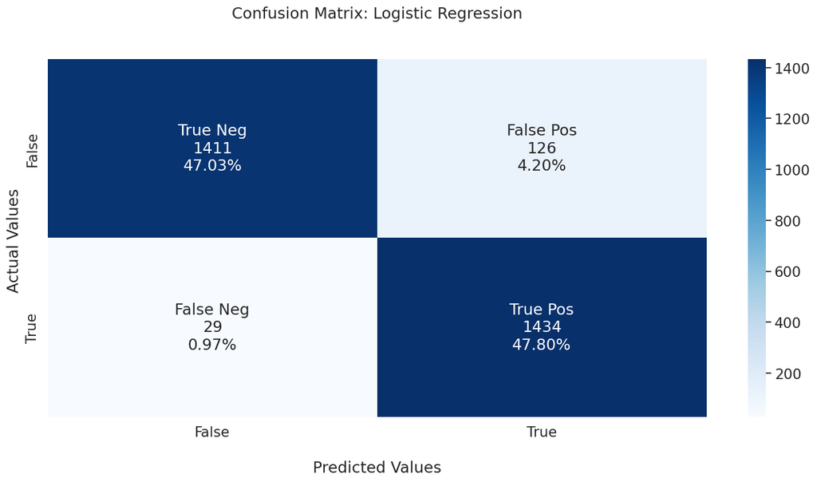

```
AUC = 0.949
```

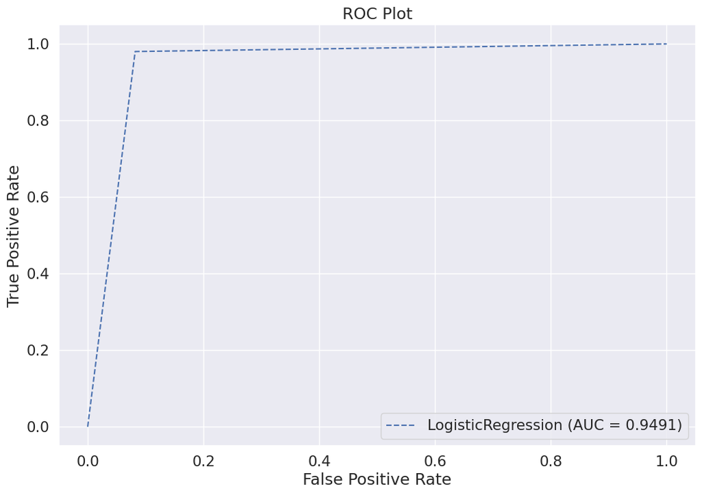

```python
# Initialize model
model1 = LogisticRegression(solver='lbfgs', max_iter=2)

# ---------------- Training time ----------------
start_train = time.time()
model1.fit(X_train, y_train)
end_train = time.time()
training_time = end_train - start_train

# ---------------- Testing time ----------------
start_test = time.time()
predictions1 = model1.predict(X_test)
end_test = time.time()
testing_time = end_test - start_test

print(f" Training Time: {training_time:.4f} seconds")
print(f" Testing Time: {testing_time:.4f} seconds")

# Accuracy
print('Accuracy :', accuracy_score(y_test, predictions1))
print("Train accuracy ={:.2f}%".format(model1.score(X_train, y_train)*100))
print("Test accuracy ={:.2f}%".format(model1.score(X_test,y_test)*100))

# Predict test dataset
y_pred_log = model1.predict(X_test)

# Confusion Matrix
print(confusion_matrix(y_test,y_pred_log))
print(classification_report(y_test, y_pred_log))
print(F'Accuracy:',accuracy_score(y_test, y_pred_log))
print(F'Precision:', precision_score(y_test, y_pred_log))
print(F'Recall:', recall_score(y_test, y_pred_log))
print(F'F1 Score:', f1_score(y_test, y_pred_log,average="micro"))
print(F'MCC:', matthews_corrcoef(y_test, y_pred_log))
print('*******************************************')

# Confusion matrix visualization
conf_matrix = confusion_matrix(y_test, y_pred_log)
group_names = ['True Neg','False Pos','False Neg','True Pos']
group_counts = ["{0:0.0f}".format(value) for value in conf_matrix.flatten()]
group_percentages = ["{0:.2%}".format(value) for value in conf_matrix.flatten()/np.sum(conf_matrix)]
labels = [f"{v1}\n{v2}\n{v3}" for v1, v2, v3 in zip(group_names,group_counts,group_percentages)]
labels = np.asarray(labels).reshape(2,2)

plt.figure(figsize=(16,7))
sns.set(font_scale=1.4)
ax = sns.heatmap(conf_matrix, annot=labels, fmt='', cmap='Blues')
ax.set_title('Confusion Matrix: Logistic Regression\n\n')
ax.set_xlabel('\nPredicted Values')
ax.set_ylabel('Actual Values ')
ax.xaxis.set_ticklabels(['False','True'])
ax.yaxis.set_ticklabels(['False','True'])
plt.show()

print('*******************************************')

# ROC Curve & AUC
lr_auc = roc_auc_score(y_test, predictions1)
print('AUC = %.3f' % (lr_auc))
lr_fpr, lr_tpr, _ = roc_curve(y_test, predictions1)

plt.figure(figsize=(12, 8))
plt.plot(lr_fpr, lr_tpr, linestyle='--', label='LogisticRegression (AUC = %0.4f)' % lr_auc)
plt.title('ROC Plot')
plt.xlabel('False Positive Rate')
plt.ylabel('True Positive Rate')
plt.legend()
plt.show()
```

```
 Training Time: 0.0083 seconds
 Testing Time: 0.0119 seconds
Accuracy : 0.6383333333333333
Train accuracy =63.00%
Test accuracy =63.83%
[[1520   17]
 [1068  395]]
              precision    recall  f1-score   support

           0       0.59      0.99      0.74      1537
           1       0.96      0.27      0.42      1463

    accuracy                           0.64      3000
   macro avg       0.77      0.63      0.58      3000
weighted avg       0.77      0.64      0.58      3000

Accuracy: 0.6383333333333333
Precision: 0.9587378640776699
Recall: 0.26999316473000684
F1 Score: 0.6383333333333333
MCC: 0.3760236675645287
```

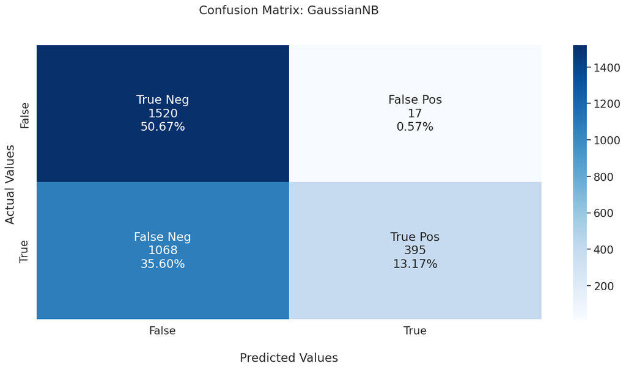

```
AUC = 0.629
```

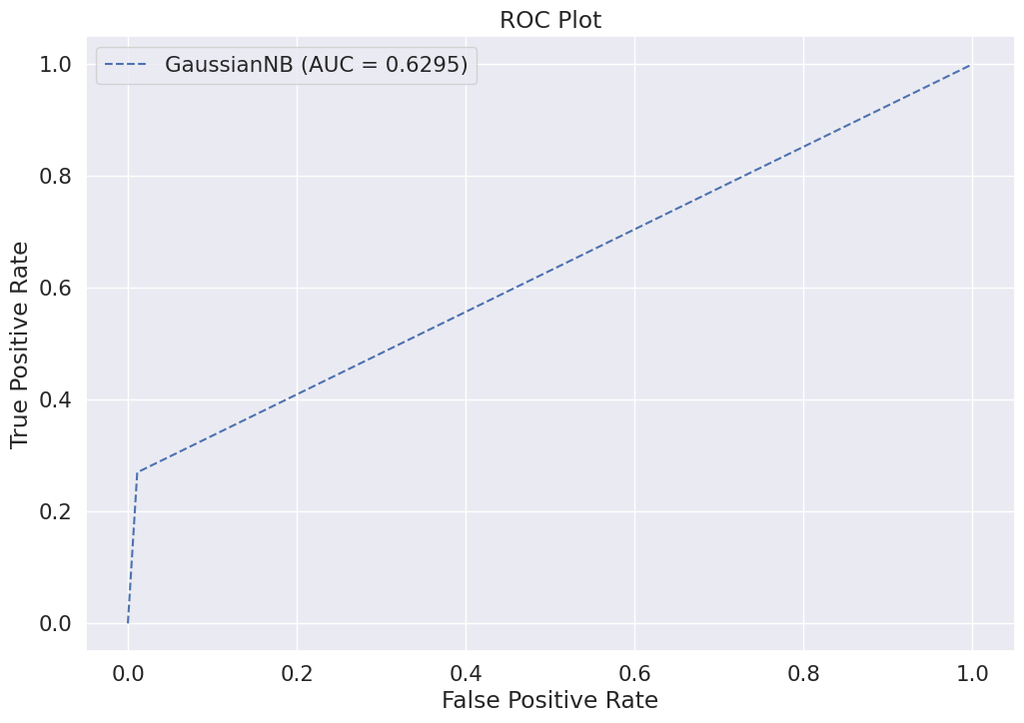

```python
# Initialize model
model2 = GaussianNB(priors=None, var_smoothing=1e-09)

# ---------------- Training time ----------------
start_train = time.time()
model2.fit(X_train, y_train)
end_train = time.time()
training_time = end_train - start_train

# ---------------- Testing time ----------------
start_test = time.time()
predictions2 = model2.predict(X_test)
end_test = time.time()
testing_time = end_test - start_test

print(f" Training Time: {training_time:.4f} seconds")
print(f" Testing Time: {testing_time:.4f} seconds")

# Accuracy
print('Accuracy :', accuracy_score(y_test, predictions2))
print("Train accuracy ={:.2f}%".format(model2.score(X_train, y_train)*100))
print("Test accuracy ={:.2f}%".format(model2.score(X_test,y_test)*100))

# Predict test dataset
y_pred_NB = model2.predict(X_test)

# Confusion Matrix
print(confusion_matrix(y_test,y_pred_NB))
print(classification_report(y_test, y_pred_NB))
print(F'Accuracy:',accuracy_score(y_test, y_pred_NB))
print(F'Precision:', precision_score(y_test, y_pred_NB))
print(F'Recall:', recall_score(y_test, y_pred_NB))
print(F'F1 Score:', f1_score(y_test, y_pred_NB,average="micro"))
print(F'MCC:', matthews_corrcoef(y_test,y_pred_NB))
print('*******************************************')

# Confusion Matrix Visualization
conf_matrix = confusion_matrix(y_test, y_pred_NB)
group_names = ['True Neg','False Pos','False Neg','True Pos']
group_counts = ["{0:0.0f}".format(value) for value in conf_matrix.flatten()]
group_percentages = ["{0:.2%}".format(value) for value in conf_matrix.flatten()/np.sum(conf_matrix)]
labels = [f"{v1}\n{v2}\n{v3}" for v1, v2, v3 in zip(group_names,group_counts,group_percentages)]
labels = np.asarray(labels).reshape(2,2)

plt.figure(figsize=(16,7))
sns.set(font_scale=1.4)
ax = sns.heatmap(conf_matrix, annot=labels, fmt='', cmap='Blues')
ax.set_title('Confusion Matrix: GaussianNB\n\n')
ax.set_xlabel('\nPredicted Values')
ax.set_ylabel('Actual Values ')
ax.xaxis.set_ticklabels(['False','True'])
ax.yaxis.set_ticklabels(['False','True'])
plt.show()

print('*******************************************')

# ROC Curve & AUC
NB_auc = roc_auc_score(y_test, predictions2)
print('AUC = %.3f' % (NB_auc))
NB_fpr, NB_tpr, _ = roc_curve(y_test, predictions2)

plt.figure(figsize=(12, 8))
plt.plot(NB_fpr, NB_tpr, linestyle='--', label='GaussianNB (AUC = %0.4f)' % NB_auc)
plt.title('ROC Plot')
plt.xlabel('False Positive Rate')
plt.ylabel('True Positive Rate')
plt.legend()
plt.show()
```

```
Training Time: 0.0174 seconds
Testing Time: 0.0008 seconds
Accuracy : 0.9813333333333333
Train accuracy =98.34%
Test accuracy =98.13%
[[1488   49]
 [   7 1456]]
              precision    recall  f1-score   support

           0       1.00      0.97      0.98      1537
           1       0.97      1.00      0.98      1463

    accuracy                           0.98      3000
   macro avg       0.98      0.98      0.98      3000
weighted avg       0.98      0.98      0.98      3000

Accuracy: 0.9813333333333333
Precision: 0.9817235954473569
Recall: 0.9813333333333333
F1 Score: 0.9813333333333333
MCC: 0.9630472624958347
```

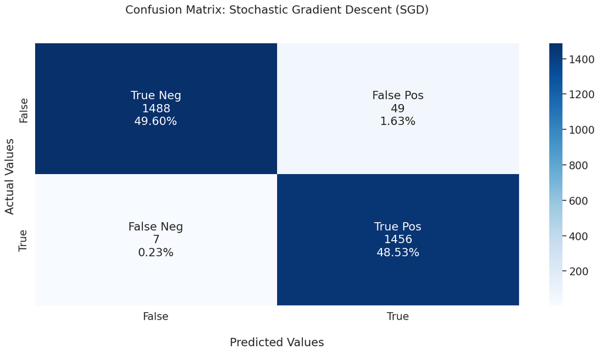

```
AUC = 0.982
```

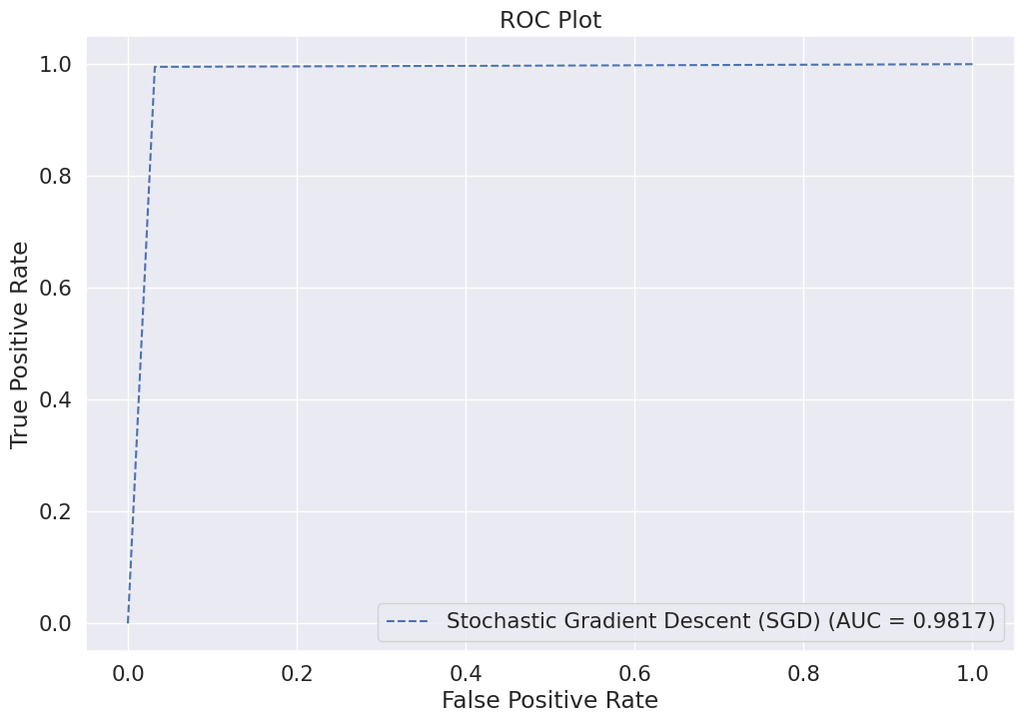

```python
import time
from sklearn.linear_model import SGDClassifier
from sklearn.metrics import (accuracy_score, confusion_matrix, classification_report,
                             precision_score, recall_score, f1_score, matthews_corrcoef,
                             roc_auc_score, roc_curve)
import matplotlib.pyplot as plt
import seaborn as sns
import numpy as np

# Initialize model
model3 = SGDClassifier(alpha=0.01)

# ---------------- Training time ----------------
start_train = time.time()
model3.fit(X_train, y_train)
end_train = time.time()
training_time = end_train - start_train

# ---------------- Testing time ----------------
start_test = time.time()
predictions3 = model3.predict(X_test)
end_test = time.time()
testing_time = end_test - start_test

print(f"Training Time: {training_time:.4f} seconds")
print(f"Testing Time: {testing_time:.4f} seconds")

# Accuracy
print('Accuracy :', accuracy_score(y_test, predictions3))
print("Train accuracy ={:.2f}%".format(model3.score(X_train, y_train)*100))
print("Test accuracy ={:.2f}%".format(model3.score(X_test, y_test)*100))

# Predict test dataset
y_pred_SGDC = model3.predict(X_test)

# Confusion Matrix
print(confusion_matrix(y_test, y_pred_SGDC))
print(classification_report(y_test, y_pred_SGDC))
print(F'Accuracy:', accuracy_score(y_test, y_pred_SGDC))
print(F'Precision:', precision_score(y_test, y_pred_SGDC, average="weighted"))
print(F'Recall:', recall_score(y_test, y_pred_SGDC, average="weighted"))
print(F'F1 Score:', f1_score(y_test, y_pred_SGDC, average="micro"))
print(F'MCC:', matthews_corrcoef(y_test, y_pred_SGDC))
print('*******************************************')

# Confusion Matrix Visualization
conf_matrix = confusion_matrix(y_test, y_pred_SGDC)
group_names = ['True Neg','False Pos','False Neg','True Pos']
group_counts = ["{0:0.0f}".format(value) for value in conf_matrix.flatten()]
group_percentages = ["{0:.2%}".format(value) for value in conf_matrix.flatten()/np.sum(conf_matrix)]
labels = [f"{v1}\n{v2}\n{v3}" for v1, v2, v3 in zip(group_names, group_counts, group_percentages)]
labels = np.asarray(labels).reshape(2,2)

plt.figure(figsize=(16,7))
sns.set(font_scale=1.4)
ax = sns.heatmap(conf_matrix, annot=labels, fmt='', cmap='Blues')
ax.set_title('Confusion Matrix: Stochastic Gradient Descent (SGD)\n\n')
ax.set_xlabel('\nPredicted Values')
ax.set_ylabel('Actual Values ')
ax.xaxis.set_ticklabels(['False','True'])
ax.yaxis.set_ticklabels(['False','True'])
plt.show()

print('*******************************************')

# ROC Curve & AUC
SGD_auc = roc_auc_score(y_test, predictions3)
print('AUC = %.3f' % (SGD_auc))
SGD_fpr, SGD_tpr, _ = roc_curve(y_test, predictions3)

plt.figure(figsize=(12, 8))
plt.plot(SGD_fpr, SGD_tpr, linestyle='--',
         label='Stochastic Gradient Descent (SGD) (AUC = %0.4f)' % SGD_auc)
plt.title('ROC Plot')
plt.xlabel('False Positive Rate')
plt.ylabel('True Positive Rate')
plt.legend()
plt.show()
```

```
Training Time: 0.0656 seconds
Testing Time: 0.0025 seconds
Accuracy : 0.981
Train accuracy =98.21%
Test accuracy =98.10%
[[1489   48]
 [   9 1454]]
              precision    recall  f1-score   support

           0       0.99      0.97      0.98      1537
           1       0.97      0.99      0.98      1463

    accuracy                           0.98      3000
   macro avg       0.98      0.98      0.98      3000
weighted avg       0.98      0.98      0.98      3000

Accuracy: 0.981
Precision: 0.9680426098535286
Recall: 0.9938482570061518
F1 Score: 0.9807757166947724
MCC: 0.9623265496975997
```

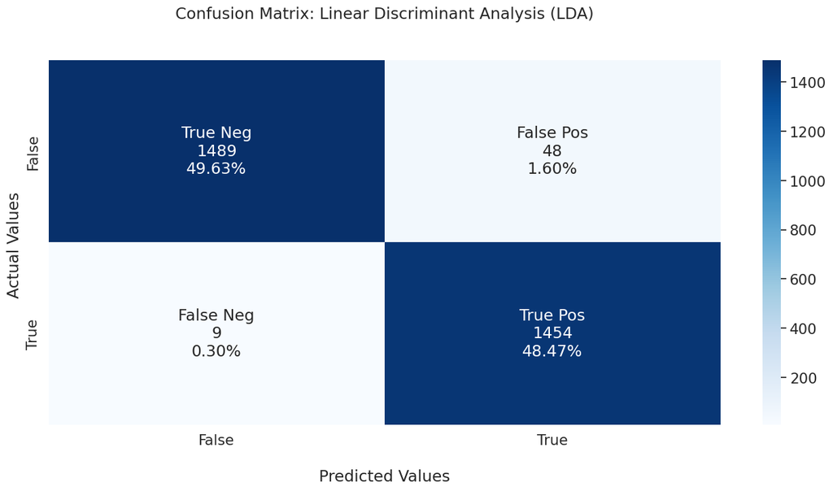

```
AUC = 0.981
```

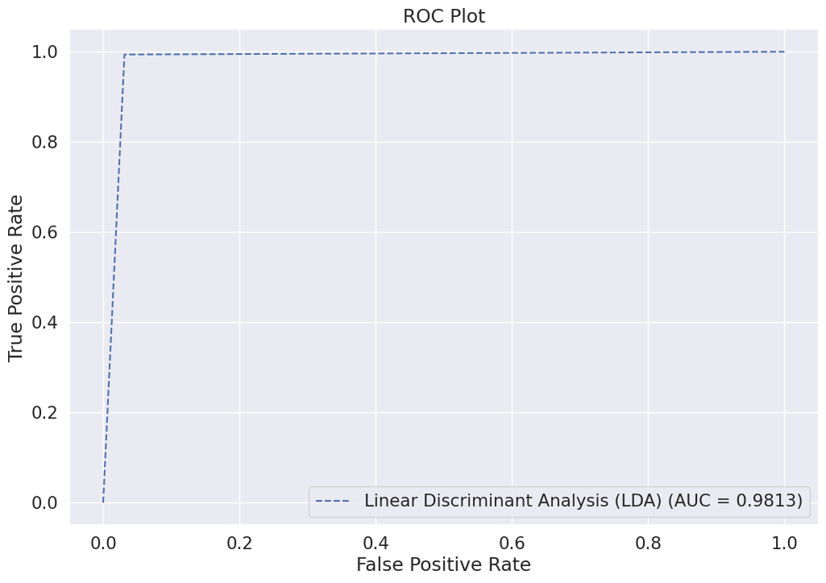

```python
# Initialize model
model4 = LinearDiscriminantAnalysis()

# ---------------- Training time ----------------
start_train = time.time()
model4.fit(X_train, y_train)
end_train = time.time()
training_time = end_train - start_train

# ---------------- Testing time ----------------
start_test = time.time()
predictions4 = model4.predict(X_test)
end_test = time.time()
testing_time = end_test - start_test

print(f"Training Time: {training_time:.4f} seconds")
print(f"Testing Time: {testing_time:.4f} seconds")

# Accuracy
print('Accuracy :', accuracy_score(y_test, predictions4))
print("Train accuracy ={:.2f}%".format(model4.score(X_train, y_train)*100))
print("Test accuracy ={:.2f}%".format(model4.score(X_test, y_test)*100))

# Predict test dataset
y_pred_LDA = model4.predict(X_test)

# Confusion Matrix & Report
print(confusion_matrix(y_test, y_pred_LDA))
print(classification_report(y_test, y_pred_LDA))
print(F'Accuracy:', accuracy_score(y_test, y_pred_LDA))
print(F'Precision:', precision_score(y_test, y_pred_LDA))
print(F'Recall:', recall_score(y_test, y_pred_LDA))
print(F'F1 Score:', f1_score(y_test, y_pred_LDA))
print(F'MCC:', matthews_corrcoef(y_test, y_pred_LDA))
print('*******************************************')

# Confusion Matrix Visualization
conf_matrix = confusion_matrix(y_test, y_pred_LDA)
group_names = ['True Neg','False Pos','False Neg','True Pos']
group_counts = ["{0:0.0f}".format(value) for value in conf_matrix.flatten()]
group_percentages = ["{0:.2%}".format(value) for value in conf_matrix.flatten()/np.sum(conf_matrix)]
labels = [f"{v1}\n{v2}\n{v3}" for v1, v2, v3 in zip(group_names, group_counts, group_percentages)]
labels = np.asarray(labels).reshape(2,2)

plt.figure(figsize=(16,7))
sns.set(font_scale=1.4)
ax = sns.heatmap(conf_matrix, annot=labels, fmt='', cmap='Blues')
ax.set_title('Confusion Matrix: Linear Discriminant Analysis (LDA)\n\n')
ax.set_xlabel('\nPredicted Values')
ax.set_ylabel('Actual Values ')
ax.xaxis.set_ticklabels(['False','True'])
ax.yaxis.set_ticklabels(['False','True'])
plt.show()

print('*******************************************')

# ROC Curve & AUC
LDA_auc = roc_auc_score(y_test, predictions4)
print('AUC = %.3f' % (LDA_auc))
LDA_fpr, LDA_tpr, _ = roc_curve(y_test, predictions4)

plt.figure(figsize=(12, 8))
plt.plot(LDA_fpr, LDA_tpr, linestyle='--',
         label='Linear Discriminant Analysis (LDA) (AUC = %0.4f)' % LDA_auc)
plt.title('ROC Plot')
plt.xlabel('False Positive Rate')
plt.ylabel('True Positive Rate')
plt.legend()
plt.show()
```

```
 Training time: 0.0014 seconds
Testing time: 0.2240 seconds
Accuracy : 0.9856666666666667
Train accuracy =98.60%
Test accuracy =98.57%
[[1500   37]
 [   6 1457]]
              precision    recall  f1-score   support

           0       1.00      0.98      0.99      1537
           1       0.98      1.00      0.99      1463

    accuracy                           0.99      3000
   macro avg       0.99      0.99      0.99      3000
weighted avg       0.99      0.99      0.99      3000

Accuracy: 0.9856666666666667
Precision: 0.9752342704149933
Recall: 0.9958988380041012
F1 Score: 0.9854582346973284
MCC: 0.9715380450724546
```

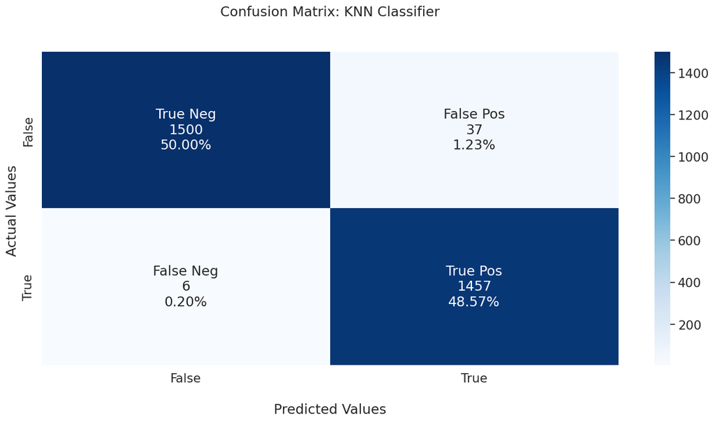

```
AUC = 0.986
```

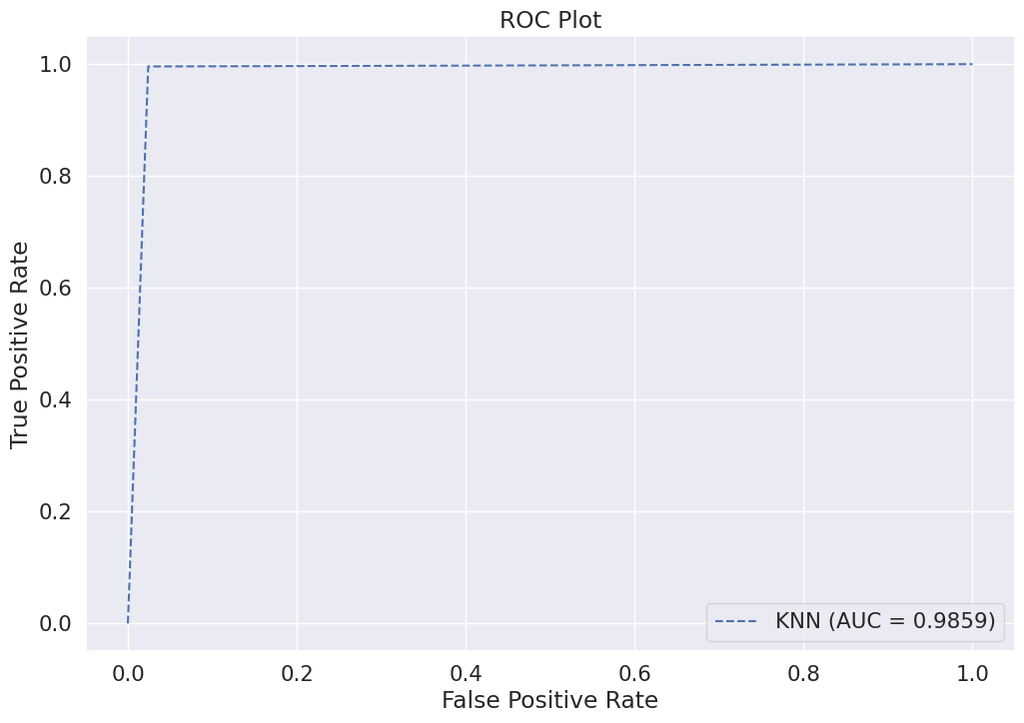

```python
# Define KNN model
model_knn = KNeighborsClassifier(n_neighbors=5, leaf_size=2, weights='uniform')

# ---------------- Train time ----------------
start_train = time.time()
model_knn.fit(X_train, y_train)
end_train = time.time()
train_time = end_train - start_train
print(f" Training time: {train_time:.4f} seconds")

# ---------------- Test time ----------------
start_test = time.time()
predictions_knn = model_knn.predict(X_test)
end_test = time.time()
test_time = end_test - start_test
print(f"Testing time: {test_time:.4f} seconds")

# Accuracy
print('Accuracy :', accuracy_score(y_test, predictions_knn))
print("Train accuracy ={:.2f}%".format(model_knn.score(X_train, y_train) * 100))
print("Test accuracy ={:.2f}%".format(model_knn.score(X_test, y_test) * 100))

# Confusion matrix
conf_matrix = confusion_matrix(y_test, predictions_knn)
print(conf_matrix)

# Classification report
print(classification_report(y_test, predictions_knn))

# Performance metrics
print(f'Accuracy: {accuracy_score(y_test, predictions_knn)}')
print(f'Precision: {precision_score(y_test, predictions_knn)}')
print(f'Recall: {recall_score(y_test, predictions_knn)}')
print(f'F1 Score: {f1_score(y_test, predictions_knn)}')
print(f'MCC: {matthews_corrcoef(y_test, predictions_knn)}')
print('*******************************************')

# Confusion matrix visualization
plt.figure(figsize=(16,7))
sns.set(font_scale=1.4)

group_names = ['True Neg','False Pos','False Neg','True Pos']
group_counts = ["{0:0.0f}".format(value) for value in conf_matrix.flatten()]
group_percentages = ["{0:.2%}".format(value) for value in conf_matrix.flatten()/np.sum(conf_matrix)]

labels = [f"{v1}\n{v2}\n{v3}" for v1, v2, v3 in zip(group_names, group_counts, group_percentages)]
labels = np.asarray(labels).reshape(2,2)

ax = sns.heatmap(conf_matrix, annot=labels, fmt='', cmap='Blues')

ax.set_title('Confusion Matrix: KNN Classifier\n\n')
ax.set_xlabel('\nPredicted Values')
ax.set_ylabel('Actual Values ')
ax.xaxis.set_ticklabels(['False','True'])
ax.yaxis.set_ticklabels(['False','True'])

plt.show()
print('*******************************************')

# ROC Curve
knn_auc = roc_auc_score(y_test, predictions_knn)
print('AUC = %.3f' % (knn_auc))
knn_fpr, knn_tpr, _ = roc_curve(y_test, predictions_knn)

plt.figure(figsize=(12, 8))
plt.plot(knn_fpr, knn_tpr, linestyle='--', label='KNN (AUC = %0.4f)' % knn_auc)

plt.title('ROC Plot')
plt.xlabel('False Positive Rate')
plt.ylabel('True Positive Rate')
plt.legend()
plt.show()
```

```python
#pip install shap
```

```python
import shap
```

```
Best Hyperparameters from Bee Algorithm:
  n_neighbors : 6
  metric      : manhattan
 Training Time: 0.0012 seconds
 Testing Time: 1.0558 seconds
 Total Time (Training + Testing): 1.0570 seconds

Model Evaluation:
Training Accuracy : 0.9859
Testing Accuracy  : 0.9850
Precision          : 0.9849
Recall             : 0.9852
F1 Score           : 0.9850
Matthews Corrcoef  : 0.9701

Classification Report:
               precision    recall  f1-score   support

           0       0.99      0.98      0.99      1537
           1       0.98      0.99      0.98      1463

    accuracy                           0.98      3000
   macro avg       0.98      0.99      0.98      3000
weighted avg       0.99      0.98      0.99      3000
```

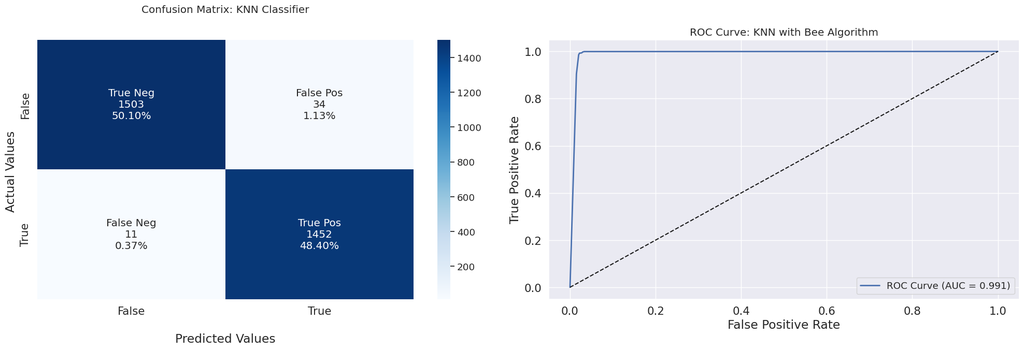

```
Confusion Matrix:
[[1503   34]
 [  11 1452]]

AUC Score: 0.991
```

```python
# Define search space for KNN
bounds = (
    np.array([1, 0]),      # Lower bounds
    np.array([30, 3])      # Upper bounds
)
cv = StratifiedKFold(n_splits=5, shuffle=True, random_state=44)

# -----------------------------------------------------------
# Objective Function
# -----------------------------------------------------------
def objective_function(params):
    losses = []
    for p in params:
        n_neighbors = int(p[0])
        metric_index = int(round(p[1]))
        metric_list = ['euclidean', 'manhattan', 'chebyshev', 'minkowski']
        metric = metric_list[metric_index]

        clf = KNeighborsClassifier(
            n_neighbors=n_neighbors,
            metric=metric
        )

        score = cross_val_score(clf, X_train, y_train, cv=cv, scoring='accuracy').mean()
        losses.append(1 - score)  # minimize loss
    return np.array(losses)

# -----------------------------------------------------------
# Bee Algorithm
# -----------------------------------------------------------
class BeeOptimizer:
    def __init__(self, n_bees, n_elite, n_best, patch_size, bounds, max_iter):
        self.n_bees = n_bees
        self.n_elite = n_elite
        self.n_best = n_best
        self.patch_size = patch_size
        self.bounds = bounds
        self.max_iter = max_iter

    def optimize(self):
        population = np.random.uniform(self.bounds[0], self.bounds[1], (self.n_bees, len(self.bounds[0])))
        best_solution = None
        best_fitness = float('inf')

        for iteration in range(self.max_iter):
            fitness = objective_function(population)

            sorted_indices = np.argsort(fitness)
            population = population[sorted_indices]
            fitness = fitness[sorted_indices]

            if fitness[0] < best_fitness:
                best_fitness = fitness[0]
                best_solution = population[0]

            new_population = []
            for i in range(self.n_elite):
                for _ in range(self.n_best):
                    candidate = population[i] + np.random.uniform(-self.patch_size, self.patch_size, len(self.bounds[0]))
                    candidate = np.clip(candidate, self.bounds[0], self.bounds[1])
                    new_population.append(candidate)

            for i in range(self.n_elite, self.n_best):
                candidate = population[i] + np.random.uniform(-self.patch_size, self.patch_size, len(self.bounds[0]))
                candidate = np.clip(candidate, self.bounds[0], self.bounds[1])
                new_population.append(candidate)

            while len(new_population) < self.n_bees:
                candidate = np.random.uniform(self.bounds[0], self.bounds[1], len(self.bounds[0]))
                new_population.append(candidate)

            population = np.array(new_population)

        return best_solution, 1 - best_fitness

# -----------------------------------------------------------
# Run Bee Algorithm
# -----------------------------------------------------------
optimizer = BeeOptimizer(n_bees=5, n_elite=5, n_best=5, patch_size=2, bounds=bounds, max_iter=5)
best_params, best_acc = optimizer.optimize()

best_n_neighbors = int(best_params[0])
best_metric = ['euclidean', 'manhattan', 'chebyshev', 'minkowski'][int(round(best_params[1]))]

print("Best Hyperparameters from Bee Algorithm:")
print(f"  n_neighbors : {best_n_neighbors}")
print(f"  metric      : {best_metric}")

# -----------------------------------------------------------
# Training + Testing with Time Measurement
# -----------------------------------------------------------
model_knn = KNeighborsClassifier(
    n_neighbors=best_n_neighbors,
    metric=best_metric
)

# Training
start_train = time.time()
model_knn.fit(X_train, y_train)
end_train = time.time()
train_time = end_train - start_train
print(f" Training Time: {train_time:.4f} seconds")

# Testing
start_test = time.time()
predictions_knn = model_knn.predict(X_test)
end_test = time.time()
test_time = end_test - start_test
print(f" Testing Time: {test_time:.4f} seconds")

# Total
print(f" Total Time (Training + Testing): {train_time + test_time:.4f} seconds")

# -----------------------------------------------------------
# Metrics
# -----------------------------------------------------------
prob_knn = model_knn.predict_proba(X_test)[:, 1] if len(np.unique(y_test)) == 2 else None

train_accuracy = accuracy_score(y_train, model_knn.predict(X_train))
test_accuracy = accuracy_score(y_test, predictions_knn)
precision = precision_score(y_test, predictions_knn, average='macro')
recall = recall_score(y_test, predictions_knn, average='macro')
f1 = f1_score(y_test, predictions_knn, average='macro')
mcc = matthews_corrcoef(y_test, predictions_knn)
report = classification_report(y_test, predictions_knn)

print("\nModel Evaluation:")
print(f"Training Accuracy : {train_accuracy:.4f}")
print(f"Testing Accuracy  : {test_accuracy:.4f}")
print(f"Precision          : {precision:.4f}")
print(f"Recall             : {recall:.4f}")
print(f"F1 Score           : {f1:.4f}")
print(f"Matthews Corrcoef  : {mcc:.4f}")
print("\nClassification Report:\n", report)

# -----------------------------------------------------------
# Confusion Matrix & ROC
# -----------------------------------------------------------
fig, (ax1, ax2) = plt.subplots(1, 2, figsize=(20, 7))
sns.set(font_scale=1.2)

conf_matrix = confusion_matrix(y_test, predictions_knn)

group_names = ['True Neg','False Pos','False Neg','True Pos']
group_counts = ["{0:0.0f}".format(value) for value in conf_matrix.flatten()]
group_percentages = ["{0:.2%}".format(value) for value in conf_matrix.flatten()/np.sum(conf_matrix)]
labels = [f"{v1}\n{v2}\n{v3}" for v1, v2, v3 in zip(group_names, group_counts, group_percentages)]
labels = np.asarray(labels).reshape(2,2)

sns.heatmap(conf_matrix, annot=labels, fmt='', cmap='Blues', ax=ax1)
ax1.set_title('Confusion Matrix: KNN Classifier\n\n')
ax1.set_xlabel('\nPredicted Values')
ax1.set_ylabel('Actual Values ')
ax1.xaxis.set_ticklabels(['False','True'])
ax1.yaxis.set_ticklabels(['False','True'])

# ROC curve
if prob_knn is not None:
    auc = roc_auc_score(y_test, prob_knn)
    fpr, tpr, _ = roc_curve(y_test, prob_knn)
    ax2.plot(fpr, tpr, label=f'ROC Curve (AUC = {auc:.3f})', linewidth=2)
    ax2.plot([0, 1], [0, 1], 'k--')
    ax2.set_xlabel('False Positive Rate')
    ax2.set_ylabel('True Positive Rate')
    ax2.set_title('ROC Curve: KNN with Bee Algorithm')
    ax2.legend(loc='lower right')
    ax2.grid(True)

plt.tight_layout()
plt.show()

print("Confusion Matrix:")
print(conf_matrix)
if prob_knn is not None:
    print(f"\nAUC Score: {auc:.3f}")
```

```python
pip install lime
```

```python
import lime
```

```python
# -----------------------------------------------------------
# LIME Explanation for KNN with Bee Optimization
# -----------------------------------------------------------
import lime
import lime.lime_tabular

# Initialize LIME explainer
explainer = lime.lime_tabular.LimeTabularExplainer(
    training_data=X_train,
    feature_names=X_train.columns if hasattr(X_train, 'columns') else [f"f{i}" for i in range(X_train.shape[1])],
    class_names=np.unique(y_train).astype(str),
    mode='classification'
)

# Select one instance from the test set
i = 0
instance = X_test[i]

if len(instance.shape) == 1:  # if 1D array, reshape
    instance = instance.reshape(1, -1)

# Generate explanation
exp = explainer.explain_instance(
    data_row=instance[0],
    predict_fn=model_knn.predict_proba,
    num_features=10  # top 10 features
)

# Show explanation in console
print("\nLIME Explanation for test instance 0:")
print(exp.as_list())

# Show explanation in notebook (requires Jupyter)
exp.show_in_notebook(show_table=True, show_all=False)

# Save explanation to HTML file
exp.save_to_file("lime_knn_bee.html")
print("\nLIME explanation saved as 'lime_knn_bee.html'")
```

[output not shown]

```
LIME explanation saved as 'lime_knn_bee.html'
```

# LSTM-Model

[output not shown]

```
Model: "LSTM-Model"
```

```
┏━━━━━━━━━━━━━━━━━━━━━━━━━━━━━━━━━┳━━━━━━━━━━━━━━━━━━━━━━━━┳━━━━━━━━━━━━━━━┓
┃ Layer (type)                    ┃ Output Shape           ┃       Param # ┃
┡━━━━━━━━━━━━━━━━━━━━━━━━━━━━━━━━━╇━━━━━━━━━━━━━━━━━━━━━━━━╇━━━━━━━━━━━━━━━┩
│ lstm (LSTM)                     │ (None, 78, 128)        │        66,560 │
├─────────────────────────────────┼────────────────────────┼───────────────┤
│ lstm_1 (LSTM)                   │ (None, 78, 64)         │        49,408 │
├─────────────────────────────────┼────────────────────────┼───────────────┤
│ dropout (Dropout)               │ (None, 78, 64)         │             0 │
├─────────────────────────────────┼────────────────────────┼───────────────┤
│ lstm_2 (LSTM)                   │ (None, 32)             │        12,416 │
├─────────────────────────────────┼────────────────────────┼───────────────┤
│ flatten (Flatten)               │ (None, 32)             │             0 │
├─────────────────────────────────┼────────────────────────┼───────────────┤
│ dense (Dense)                   │ (None, 32)             │         1,056 │
├─────────────────────────────────┼────────────────────────┼───────────────┤
│ dropout_1 (Dropout)             │ (None, 32)             │             0 │
├─────────────────────────────────┼────────────────────────┼───────────────┤
│ dense_1 (Dense)                 │ (None, 1)              │            33 │
├─────────────────────────────────┼────────────────────────┼───────────────┤
│ activation (Activation)         │ (None, 1)              │             0 │
└─────────────────────────────────┴────────────────────────┴───────────────┘
```

```
 Total params: 129,473 (505.75 KB)
```

```
 Trainable params: 129,473 (505.75 KB)
```

```
 Non-trainable params: 0 (0.00 B)
```

```
I0000 00:00:1759165543.329651      75 cuda_dnn.cc:529] Loaded cuDNN version 90300
```

```
28/28 ━━━━━━━━━━━━━━━━━━━━ 8s 51ms/step - accuracy: 0.6834 - loss: 0.6564 - val_accuracy: 0.6987 - val_loss: 0.5072
28/28 ━━━━━━━━━━━━━━━━━━━━ 1s 22ms/step - accuracy: 0.7381 - loss: 0.4617 - val_accuracy: 0.8210 - val_loss: 0.3686
28/28 ━━━━━━━━━━━━━━━━━━━━ 1s 22ms/step - accuracy: 0.8321 - loss: 0.3580 - val_accuracy: 0.8497 - val_loss: 0.3291
28/28 ━━━━━━━━━━━━━━━━━━━━ 1s 22ms/step - accuracy: 0.8529 - loss: 0.3152 - val_accuracy: 0.8873 - val_loss: 0.2703
28/28 ━━━━━━━━━━━━━━━━━━━━ 1s 22ms/step - accuracy: 0.8955 - loss: 0.2601 - val_accuracy: 0.9193 - val_loss: 0.2712
28/28 ━━━━━━━━━━━━━━━━━━━━ 1s 22ms/step - accuracy: 0.9227 - loss: 0.2270 - val_accuracy: 0.9540 - val_loss: 0.1484
28/28 ━━━━━━━━━━━━━━━━━━━━ 1s 22ms/step - accuracy: 0.9544 - loss: 0.1584 - val_accuracy: 0.9593 - val_loss: 0.1304
28/28 ━━━━━━━━━━━━━━━━━━━━ 1s 22ms/step - accuracy: 0.9343 - loss: 0.1911 - val_accuracy: 0.9660 - val_loss: 0.1388
28/28 ━━━━━━━━━━━━━━━━━━━━ 1s 22ms/step - accuracy: 0.9699 - loss: 0.1189 - val_accuracy: 0.9690 - val_loss: 0.1113
28/28 ━━━━━━━━━━━━━━━━━━━━ 1s 22ms/step - accuracy: 0.9753 - loss: 0.1024 - val_accuracy: 0.9640 - val_loss: 0.1166
 Training Time: 13.5244 seconds
 Testing Time: 1.7235 seconds
 Total Time (Training + Testing): 15.2478 seconds

Test Accuracy: 0.9640
Precision: 0.9513657561625583
Recall: 0.9760765550239234
F1 Score: 0.9635627530364372
Matthews Correlation Coefficient: 0.928299102857001
ROC AUC Score: 0.988700458189894
Classification Report:
               precision    recall  f1-score   support

           0       0.98      0.95      0.96      1537
           1       0.95      0.98      0.96      1463

    accuracy                           0.96      3000
   macro avg       0.96      0.96      0.96      3000
weighted avg       0.96      0.96      0.96      3000
```

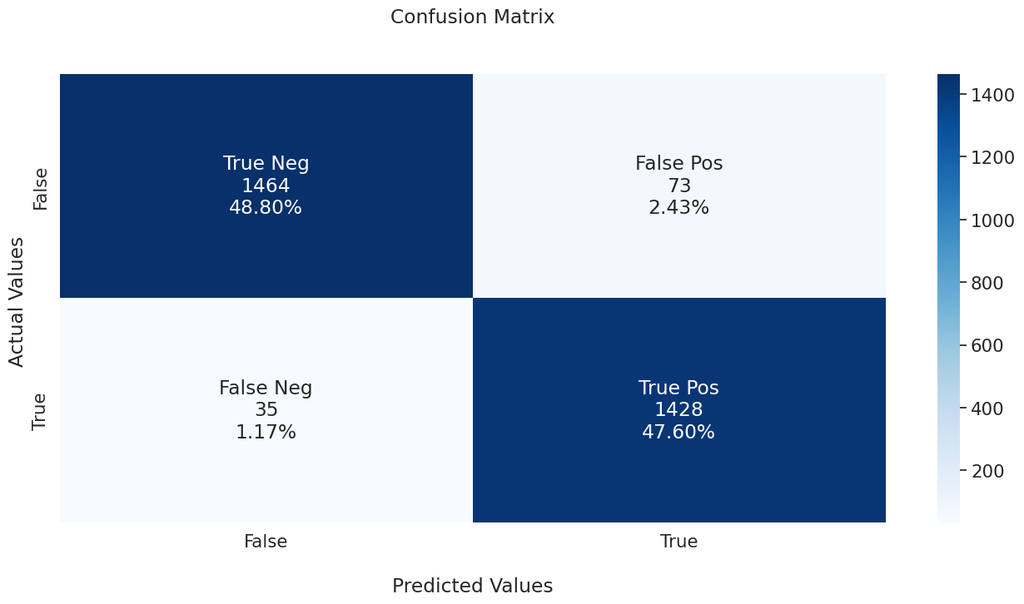

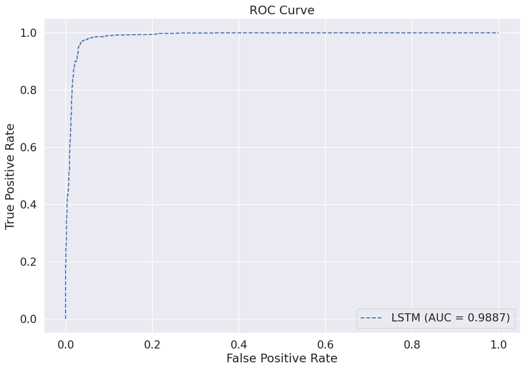

```python
# -----------------------------------------------------------
# Build Model
# -----------------------------------------------------------
model_1 = Sequential(name="LSTM-Model")
model_1.add(LSTM(units=128, input_shape=(78,1), return_sequences=True))
model_1.add(LSTM(units=64, return_sequences=True))
model_1.add(Dropout(0.01))
model_1.add(LSTM(32))
model_1.add(Flatten())
model_1.add(Dense(units=32, activation='relu'))
model_1.add(Dropout(0.01))
model_1.add(Dense(units=1))
model_1.add(Activation('sigmoid'))
model_1.summary()

# Compile
model_1.compile(loss='binary_crossentropy', optimizer='adam', metrics=['accuracy'])

# -----------------------------------------------------------
# Training with time measurement
# -----------------------------------------------------------
start_train = time.time()
history = model_1.fit(
    X_train, y_train,
    epochs=10,
    batch_size=256,
    validation_data=(X_test, y_test),
    verbose=1,
    shuffle=False
)
end_train = time.time()
train_time = end_train - start_train
print(f" Training Time: {train_time:.4f} seconds")

# -----------------------------------------------------------
# Testing with time measurement
# -----------------------------------------------------------
start_test = time.time()
loss, accuracy = model_1.evaluate(X_test, y_test, verbose=0)
y_pred_prob = model_1.predict(X_test, verbose=0)
end_test = time.time()
test_time = end_test - start_test
print(f" Testing Time: {test_time:.4f} seconds")
print(f" Total Time (Training + Testing): {train_time + test_time:.4f} seconds")

print(f"\nTest Accuracy: {accuracy:.4f}")

# -----------------------------------------------------------
# Predictions and Metrics
# -----------------------------------------------------------
y_pred = np.round(y_pred_prob).astype(int)

precision = precision_score(y_test, y_pred)
recall = recall_score(y_test, y_pred)
f1 = f1_score(y_test, y_pred)
mcc = matthews_corrcoef(y_test, y_pred)
roc_auc1 = roc_auc_score(y_test, y_pred_prob)

print(f"Precision: {precision}")
print(f"Recall: {recall}")
print(f"F1 Score: {f1}")
print(f"Matthews Correlation Coefficient: {mcc}")
print(f"ROC AUC Score: {roc_auc1}")
print("Classification Report:\n", classification_report(y_test, y_pred))

# -----------------------------------------------------------
# Confusion Matrix
# -----------------------------------------------------------
conf_matrix = confusion_matrix(y_test, y_pred)

plt.figure(figsize=(16, 7))
sns.set(font_scale=1.4)
group_names = ['True Neg', 'False Pos', 'False Neg', 'True Pos']
group_counts = ["{0:0.0f}".format(value) for value in conf_matrix.flatten()]
group_percentages = ["{0:.2%}".format(value) for value in conf_matrix.flatten()/np.sum(conf_matrix)]
labels = [f"{v1}\n{v2}\n{v3}" for v1, v2, v3 in zip(group_names, group_counts, group_percentages)]
labels = np.asarray(labels).reshape(2, 2)

ax = sns.heatmap(conf_matrix, annot=labels, fmt='', cmap='Blues')
ax.set_title('Confusion Matrix\n\n')
ax.set_xlabel('\nPredicted Values')
ax.set_ylabel('Actual Values ')
ax.xaxis.set_ticklabels(['False', 'True'])
ax.yaxis.set_ticklabels(['False', 'True'])
plt.show()

print('*******************************************')

# -----------------------------------------------------------
# ROC Curve
# -----------------------------------------------------------
fpr1, tpr1, _ = roc_curve(y_test, y_pred_prob)
plt.figure(figsize=(12, 8))
plt.plot(fpr1, tpr1, linestyle='--', label=f'LSTM (AUC = {roc_auc1:.4f})')
plt.title('ROC Curve')
plt.xlabel('False Positive Rate')
plt.ylabel('True Positive Rate')
plt.legend()
plt.show()
```

# CNN-Model

```
Model: "sequential"
```

```
┏━━━━━━━━━━━━━━━━━━━━━━━━━━━━━━━━━┳━━━━━━━━━━━━━━━━━━━━━━━━┳━━━━━━━━━━━━━━━┓
┃ Layer (type)                    ┃ Output Shape           ┃       Param # ┃
┡━━━━━━━━━━━━━━━━━━━━━━━━━━━━━━━━━╇━━━━━━━━━━━━━━━━━━━━━━━━╇━━━━━━━━━━━━━━━┩
│ conv1d (Conv1D)                 │ (None, 76, 128)        │           512 │
├─────────────────────────────────┼────────────────────────┼───────────────┤
│ average_pooling1d               │ (None, 38, 128)        │             0 │
│ (AveragePooling1D)              │                        │               │
├─────────────────────────────────┼────────────────────────┼───────────────┤
│ dropout_2 (Dropout)             │ (None, 38, 128)        │             0 │
├─────────────────────────────────┼────────────────────────┼───────────────┤
│ flatten_1 (Flatten)             │ (None, 4864)           │             0 │
├─────────────────────────────────┼────────────────────────┼───────────────┤
│ dense_2 (Dense)                 │ (None, 128)            │       622,720 │
├─────────────────────────────────┼────────────────────────┼───────────────┤
│ dropout_3 (Dropout)             │ (None, 128)            │             0 │
├─────────────────────────────────┼────────────────────────┼───────────────┤
│ dense_3 (Dense)                 │ (None, 1)              │           129 │
├─────────────────────────────────┼────────────────────────┼───────────────┤
│ activation_1 (Activation)       │ (None, 1)              │             0 │
└─────────────────────────────────┴────────────────────────┴───────────────┘
```

```
 Total params: 623,361 (2.38 MB)
```

```
 Trainable params: 623,361 (2.38 MB)
```

```
 Non-trainable params: 0 (0.00 B)
```

```
WARNING: All log messages before absl::InitializeLog() is called are written to STDERR
I0000 00:00:1759165556.487436      76 service.cc:148] XLA service 0xd0f3bda0 initialized for platform CUDA (this does not guarantee that XLA will be used). Devices:
I0000 00:00:1759165556.488182      76 service.cc:156]   StreamExecutor device (0): Tesla T4, Compute Capability 7.5
I0000 00:00:1759165556.488203      76 service.cc:156]   StreamExecutor device (1): Tesla T4, Compute Capability 7.5
```

```
18/28 ━━━━━━━━━━━━━━━━━━━━ 0s 3ms/step - accuracy: 0.7867 - loss: 0.5402
```

```
I0000 00:00:1759165559.446838      76 device_compiler.h:188] Compiled cluster using XLA!  This line is logged at most once for the lifetime of the process.
```

```
28/28 ━━━━━━━━━━━━━━━━━━━━ 8s 98ms/step - accuracy: 0.8235 - loss: 0.4774 - val_accuracy: 0.9723 - val_loss: 0.2075
28/28 ━━━━━━━━━━━━━━━━━━━━ 0s 6ms/step - accuracy: 0.9674 - loss: 0.1590 - val_accuracy: 0.9770 - val_loss: 0.1374
28/28 ━━━━━━━━━━━━━━━━━━━━ 0s 6ms/step - accuracy: 0.9765 - loss: 0.1487 - val_accuracy: 0.9790 - val_loss: 0.1025
28/28 ━━━━━━━━━━━━━━━━━━━━ 0s 6ms/step - accuracy: 0.9796 - loss: 0.1114 - val_accuracy: 0.9807 - val_loss: 0.0831
28/28 ━━━━━━━━━━━━━━━━━━━━ 0s 6ms/step - accuracy: 0.9798 - loss: 0.1122 - val_accuracy: 0.9817 - val_loss: 0.0757
28/28 ━━━━━━━━━━━━━━━━━━━━ 0s 6ms/step - accuracy: 0.9796 - loss: 0.1092 - val_accuracy: 0.9820 - val_loss: 0.0731
28/28 ━━━━━━━━━━━━━━━━━━━━ 0s 6ms/step - accuracy: 0.9791 - loss: 0.1100 - val_accuracy: 0.9820 - val_loss: 0.0709
28/28 ━━━━━━━━━━━━━━━━━━━━ 0s 6ms/step - accuracy: 0.9807 - loss: 0.0921 - val_accuracy: 0.9820 - val_loss: 0.0720
28/28 ━━━━━━━━━━━━━━━━━━━━ 0s 6ms/step - accuracy: 0.9809 - loss: 0.1028 - val_accuracy: 0.9823 - val_loss: 0.0692
28/28 ━━━━━━━━━━━━━━━━━━━━ 0s 6ms/step - accuracy: 0.9806 - loss: 0.0990 - val_accuracy: 0.9823 - val_loss: 0.0692
Training Time: 9.34 seconds
94/94 ━━━━━━━━━━━━━━━━━━━━ 1s 6ms/step - accuracy: 0.9800 - loss: 0.0787
Testing Time: 0.86 seconds
Test Accuracy: 0.9823333621025085
94/94 ━━━━━━━━━━━━━━━━━━━━ 1s 4ms/step
Accuracy: 0.9823333333333333
Precision: 0.96875
Recall: 0.9958988380041012
F1 Score: 0.9821368385574655
Matthews Correlation Coefficient: 0.9650295027132577
ROC AUC Score: 0.992459411971106
Classification Report:
               precision    recall  f1-score   support

           0       1.00      0.97      0.98      1537
           1       0.97      1.00      0.98      1463

    accuracy                           0.98      3000
   macro avg       0.98      0.98      0.98      3000
weighted avg       0.98      0.98      0.98      3000
```

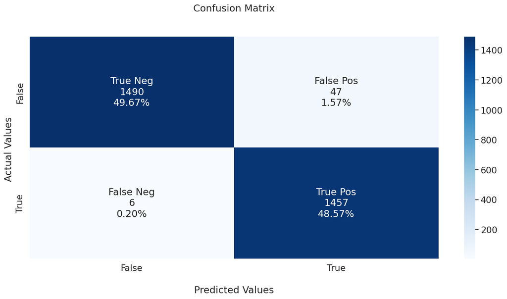

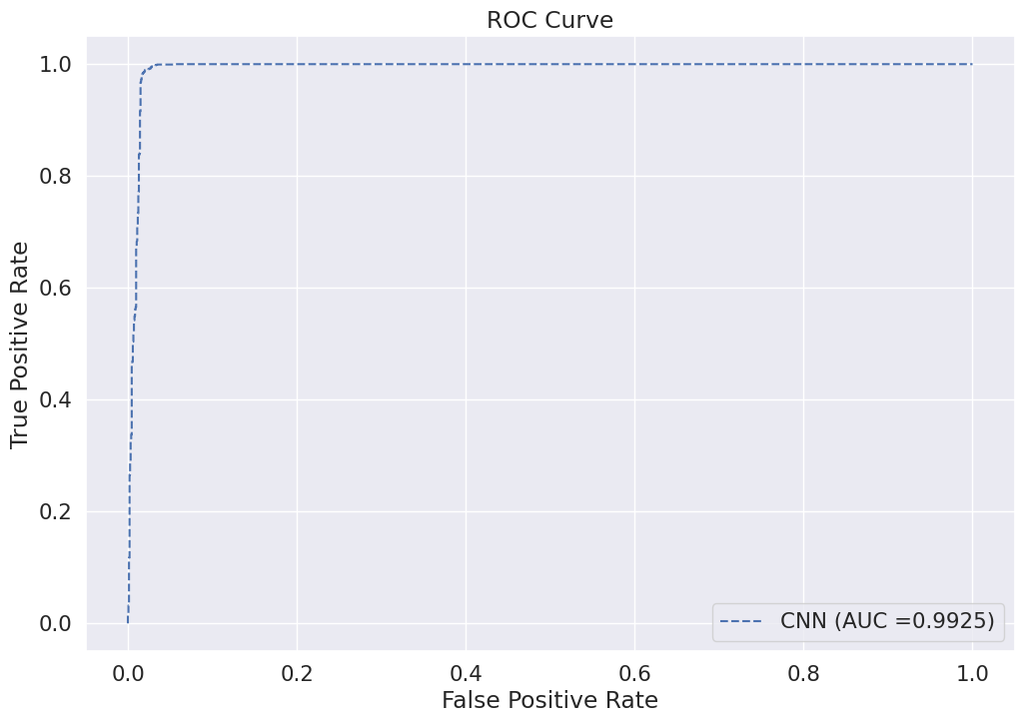

```python
model_2 = Sequential()
model_2.add(Conv1D(128, 3, activation='relu', input_shape=(78,1)))
model_2.add(AveragePooling1D(pool_size=2))
model_2.add(Dropout(0.75))
model_2.add(Flatten())
model_2.add(Dense(units = 128, activation='relu'))
model_2.add(Dropout(0.75))
model_2.add(Dense(units = 1))
model_2.add(Activation('sigmoid'))

model_2.summary()

# Compile the model
model_2.compile(loss='binary_crossentropy', optimizer='adam', metrics=['accuracy'])

# Track training time
start_train = time.time()
history = model_2.fit(
    X_train, y_train,
    epochs=10,
    batch_size=256,
    validation_data=(X_test, y_test),
    verbose=1,
    shuffle=False
)
end_train = time.time()
training_time = end_train - start_train
print(f"Training Time: {training_time:.2f} seconds")

# Track testing (evaluation) time
start_test = time.time()
loss, accuracy = model_2.evaluate(X_test, y_test)
end_test = time.time()
testing_time = end_test - start_test
print(f"Testing Time: {testing_time:.2f} seconds")

print(f"Test Accuracy: {accuracy}")

# Make predictions
y_pred_prob = model_2.predict(X_test)
y_pred = np.round(y_pred_prob).astype(int)  # Convert predictions to binary

# Calculate various metrics
accuracy = accuracy_score(y_test, y_pred)
precision = precision_score(y_test, y_pred)
recall = recall_score(y_test, y_pred)
f1 = f1_score(y_test, y_pred)
mcc = matthews_corrcoef(y_test, y_pred)
roc_auc2 = roc_auc_score(y_test, y_pred_prob)

# Print metrics
print(f"Accuracy: {accuracy}")
print(f"Precision: {precision}")
print(f"Recall: {recall}")
print(f"F1 Score: {f1}")
print(f"Matthews Correlation Coefficient: {mcc}")
print(f"ROC AUC Score: {roc_auc2}")
print("Classification Report:\n", classification_report(y_test, y_pred))

# Confusion matrix
conf_matrix = confusion_matrix(y_test, y_pred)

plt.figure(figsize=(16, 7))
sns.set(font_scale=1.4)

group_names = ['True Neg', 'False Pos', 'False Neg', 'True Pos']
group_counts = ["{0:0.0f}".format(value) for value in conf_matrix.flatten()]
group_percentages = ["{0:.2%}".format(value) for value in conf_matrix.flatten()/np.sum(conf_matrix)]

labels = [f"{v1}\n{v2}\n{v3}" for v1, v2, v3 in zip(group_names, group_counts, group_percentages)]
labels = np.asarray(labels).reshape(2, 2)

ax = sns.heatmap(conf_matrix, annot=labels, fmt='', cmap='Blues')
ax.set_title('Confusion Matrix\n\n')
ax.set_xlabel('\nPredicted Values')
ax.set_ylabel('Actual Values ')
ax.xaxis.set_ticklabels(['False', 'True'])
ax.yaxis.set_ticklabels(['False', 'True'])

plt.show()

print('*******************************************')

# ROC curve and AUC
fpr2, tpr2, _ = roc_curve(y_test, y_pred_prob)

plt.figure(figsize=(12, 8))
plt.plot(fpr2, tpr2, linestyle='--', label=f'CNN (AUC ={roc_auc2:.4f})')

plt.title('ROC Curve')
plt.xlabel('False Positive Rate')
plt.ylabel('True Positive Rate')
plt.legend()
plt.show()
```

# ANN-1-Model

```
Model: "sequential_1"
```

```
┏━━━━━━━━━━━━━━━━━━━━━━━━━━━━━━━━━┳━━━━━━━━━━━━━━━━━━━━━━━━┳━━━━━━━━━━━━━━━┓
┃ Layer (type)                    ┃ Output Shape           ┃       Param # ┃
┡━━━━━━━━━━━━━━━━━━━━━━━━━━━━━━━━━╇━━━━━━━━━━━━━━━━━━━━━━━━╇━━━━━━━━━━━━━━━┩
│ dense_4 (Dense)                 │ (None, 1024)           │        80,896 │
├─────────────────────────────────┼────────────────────────┼───────────────┤
│ dropout_4 (Dropout)             │ (None, 1024)           │             0 │
├─────────────────────────────────┼────────────────────────┼───────────────┤
│ batch_normalization             │ (None, 1024)           │         4,096 │
│ (BatchNormalization)            │                        │               │
├─────────────────────────────────┼────────────────────────┼───────────────┤
│ dense_5 (Dense)                 │ (None, 1024)           │     1,049,600 │
├─────────────────────────────────┼────────────────────────┼───────────────┤
│ dropout_5 (Dropout)             │ (None, 1024)           │             0 │
├─────────────────────────────────┼────────────────────────┼───────────────┤
│ batch_normalization_1           │ (None, 1024)           │         4,096 │
│ (BatchNormalization)            │                        │               │
├─────────────────────────────────┼────────────────────────┼───────────────┤
│ dense_6 (Dense)                 │ (None, 500)            │       512,500 │
├─────────────────────────────────┼────────────────────────┼───────────────┤
│ dropout_6 (Dropout)             │ (None, 500)            │             0 │
├─────────────────────────────────┼────────────────────────┼───────────────┤
│ batch_normalization_2           │ (None, 500)            │         2,000 │
│ (BatchNormalization)            │                        │               │
├─────────────────────────────────┼────────────────────────┼───────────────┤
│ dense_7 (Dense)                 │ (None, 250)            │       125,250 │
├─────────────────────────────────┼────────────────────────┼───────────────┤
│ dropout_7 (Dropout)             │ (None, 250)            │             0 │
├─────────────────────────────────┼────────────────────────┼───────────────┤
│ batch_normalization_3           │ (None, 250)            │         1,000 │
│ (BatchNormalization)            │                        │               │
├─────────────────────────────────┼────────────────────────┼───────────────┤
│ dense_8 (Dense)                 │ (None, 50)             │        12,550 │
├─────────────────────────────────┼────────────────────────┼───────────────┤
│ dropout_8 (Dropout)             │ (None, 50)             │             0 │
├─────────────────────────────────┼────────────────────────┼───────────────┤
│ batch_normalization_4           │ (None, 50)             │           200 │
│ (BatchNormalization)            │                        │               │
├─────────────────────────────────┼────────────────────────┼───────────────┤
│ dense_9 (Dense)                 │ (None, 1)              │            51 │
└─────────────────────────────────┴────────────────────────┴───────────────┘
```

```
 Total params: 1,792,239 (6.84 MB)
```

```
 Trainable params: 1,786,543 (6.82 MB)
```

```
 Non-trainable params: 5,696 (22.25 KB)
```

```
28/28 ━━━━━━━━━━━━━━━━━━━━ 16s 211ms/step - accuracy: 0.6967 - loss: 0.5929 - val_accuracy: 0.9723 - val_loss: 0.1535
28/28 ━━━━━━━━━━━━━━━━━━━━ 0s 7ms/step - accuracy: 0.9718 - loss: 0.1311 - val_accuracy: 0.9840 - val_loss: 0.0724
28/28 ━━━━━━━━━━━━━━━━━━━━ 0s 7ms/step - accuracy: 0.9767 - loss: 0.0989 - val_accuracy: 0.9850 - val_loss: 0.0646
28/28 ━━━━━━━━━━━━━━━━━━━━ 0s 7ms/step - accuracy: 0.9826 - loss: 0.0852 - val_accuracy: 0.9857 - val_loss: 0.0641
28/28 ━━━━━━━━━━━━━━━━━━━━ 0s 7ms/step - accuracy: 0.9813 - loss: 0.0797 - val_accuracy: 0.9847 - val_loss: 0.0643
28/28 ━━━━━━━━━━━━━━━━━━━━ 0s 7ms/step - accuracy: 0.9843 - loss: 0.0730 - val_accuracy: 0.9853 - val_loss: 0.0632
28/28 ━━━━━━━━━━━━━━━━━━━━ 0s 7ms/step - accuracy: 0.9844 - loss: 0.0699 - val_accuracy: 0.9843 - val_loss: 0.0630
28/28 ━━━━━━━━━━━━━━━━━━━━ 0s 7ms/step - accuracy: 0.9854 - loss: 0.0691 - val_accuracy: 0.9840 - val_loss: 0.0634
28/28 ━━━━━━━━━━━━━━━━━━━━ 0s 7ms/step - accuracy: 0.9849 - loss: 0.0624 - val_accuracy: 0.9850 - val_loss: 0.0616
28/28 ━━━━━━━━━━━━━━━━━━━━ 0s 7ms/step - accuracy: 0.9849 - loss: 0.0712 - val_accuracy: 0.9843 - val_loss: 0.0641
Training Time: 17.97 seconds
94/94 ━━━━━━━━━━━━━━━━━━━━ 1s 7ms/step - accuracy: 0.9816 - loss: 0.0778
Testing Time: 1.13 seconds
Total Time (Training + Testing): 19.10 seconds
Test Accuracy: 0.984333336353302
94/94 ━━━━━━━━━━━━━━━━━━━━ 1s 5ms/step
Accuracy: 0.9843333333333333
Precision: 0.9790257104194858
Recall: 0.9890635680109364
F1 Score: 0.9840190411424685
Matthews Correlation Coefficient: 0.9687037983276616
ROC AUC Score: 0.9927798291493803
Classification Report:
               precision    recall  f1-score   support

           0       0.99      0.98      0.98      1537
           1       0.98      0.99      0.98      1463

    accuracy                           0.98      3000
   macro avg       0.98      0.98      0.98      3000
weighted avg       0.98      0.98      0.98      3000
```

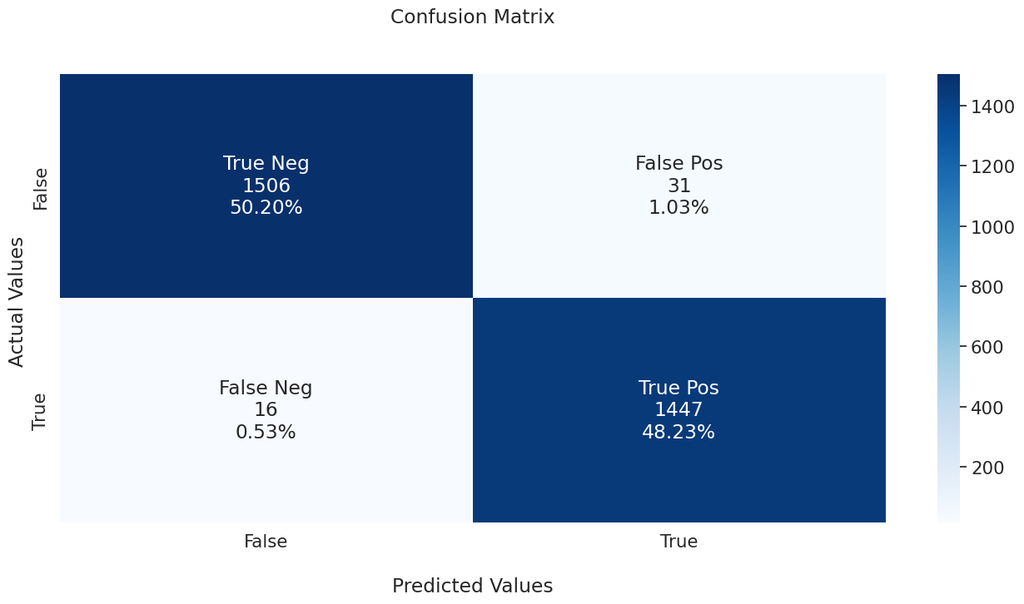

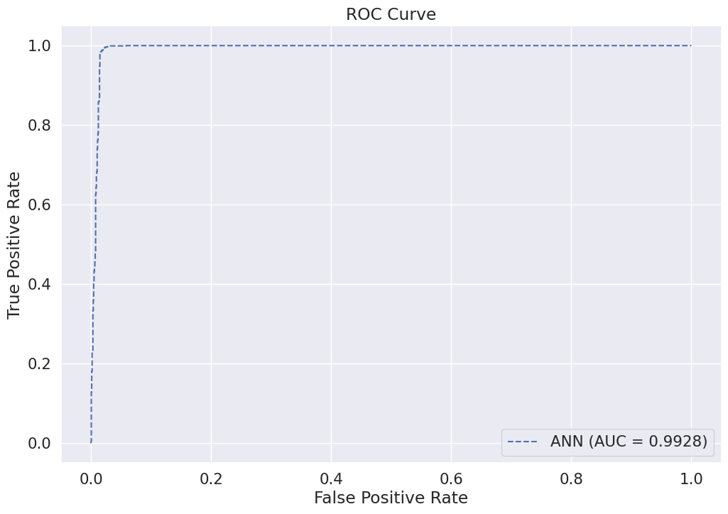

```python
# Create the ANN model
model_3 = Sequential()
model_3.add(Dense(1024, activation='relu', input_shape=(78,), kernel_constraint=MaxNorm(3)))
model_3.add(Dropout(0.5))
model_3.add(BatchNormalization())

model_3.add(Dense(1024, activation='relu', kernel_constraint=MaxNorm(3)))
model_3.add(Dropout(0.5))
model_3.add(BatchNormalization())

model_3.add(Dense(500, activation='relu', kernel_constraint=MaxNorm(3)))
model_3.add(Dropout(0.5))
model_3.add(BatchNormalization())

model_3.add(Dense(250, activation='relu', kernel_constraint=MaxNorm(3)))
model_3.add(Dropout(0.5))
model_3.add(BatchNormalization())

model_3.add(Dense(50, activation='relu', kernel_constraint=MaxNorm(3)))
model_3.add(Dropout(0.5))
model_3.add(BatchNormalization())

model_3.add(Dense(1, activation='sigmoid', kernel_constraint=MaxNorm(3)))
model_3.summary()

# Compile the model
model_3.compile(loss='binary_crossentropy', optimizer='adam', metrics=['accuracy'])

# Training time
start_train = time.time()
history = model_3.fit(X_train, y_train, epochs=10, batch_size=256,
                      validation_data=(X_test, y_test), verbose=1, shuffle=False)
end_train = time.time()
training_time = end_train - start_train
print(f"Training Time: {training_time:.2f} seconds")

# Testing time
start_test = time.time()
loss, accuracy = model_3.evaluate(X_test, y_test)
end_test = time.time()
testing_time = end_test - start_test
print(f"Testing Time: {testing_time:.2f} seconds")

# Total time
total_time = training_time + testing_time
print(f"Total Time (Training + Testing): {total_time:.2f} seconds")

print(f"Test Accuracy: {accuracy}")

# Make predictions
y_pred_prob = model_3.predict(X_test)
y_pred = np.round(y_pred_prob).astype(int)

# Calculate various metrics
accuracy = accuracy_score(y_test, y_pred)
precision = precision_score(y_test, y_pred)
recall = recall_score(y_test, y_pred)
f1 = f1_score(y_test, y_pred)
mcc = matthews_corrcoef(y_test, y_pred)
roc_auc3 = roc_auc_score(y_test, y_pred_prob)

# Print metrics
print(f"Accuracy: {accuracy}")
print(f"Precision: {precision}")
print(f"Recall: {recall}")
print(f"F1 Score: {f1}")
print(f"Matthews Correlation Coefficient: {mcc}")
print(f"ROC AUC Score: {roc_auc3}")
print("Classification Report:\n", classification_report(y_test, y_pred))

# Confusion matrix
conf_matrix = confusion_matrix(y_test, y_pred)

plt.figure(figsize=(16, 7))
sns.set(font_scale=1.4)

group_names = ['True Neg', 'False Pos', 'False Neg', 'True Pos']
group_counts = ["{0:0.0f}".format(value) for value in conf_matrix.flatten()]
group_percentages = ["{0:.2%}".format(value) for value in conf_matrix.flatten()/np.sum(conf_matrix)]

labels = [f"{v1}\n{v2}\n{v3}" for v1, v2, v3 in zip(group_names, group_counts, group_percentages)]
labels = np.asarray(labels).reshape(2, 2)

ax = sns.heatmap(conf_matrix, annot=labels, fmt='', cmap='Blues')
ax.set_title('Confusion Matrix\n\n')
ax.set_xlabel('\nPredicted Values')
ax.set_ylabel('Actual Values ')
ax.xaxis.set_ticklabels(['False', 'True'])
ax.yaxis.set_ticklabels(['False', 'True'])
plt.show()

print('*******************************************')

# ROC curve and AUC
fpr3, tpr3, _ = roc_curve(y_test, y_pred_prob)

plt.figure(figsize=(12, 8))
plt.plot(fpr3, tpr3, linestyle='--', label=f'ANN (AUC = {roc_auc3:.4f})')
plt.title('ROC Curve')
plt.xlabel('False Positive Rate')
plt.ylabel('True Positive Rate')
plt.legend()
plt.show()
```

# ANN-2-Model

```
Model: "sequential_2"
```

```
┏━━━━━━━━━━━━━━━━━━━━━━━━━━━━━━━━━┳━━━━━━━━━━━━━━━━━━━━━━━━┳━━━━━━━━━━━━━━━┓
┃ Layer (type)                    ┃ Output Shape           ┃       Param # ┃
┡━━━━━━━━━━━━━━━━━━━━━━━━━━━━━━━━━╇━━━━━━━━━━━━━━━━━━━━━━━━╇━━━━━━━━━━━━━━━┩
│ dense_10 (Dense)                │ (None, 1000)           │        79,000 │
├─────────────────────────────────┼────────────────────────┼───────────────┤
│ dropout_9 (Dropout)             │ (None, 1000)           │             0 │
├─────────────────────────────────┼────────────────────────┼───────────────┤
│ batch_normalization_5           │ (None, 1000)           │         4,000 │
│ (BatchNormalization)            │                        │               │
├─────────────────────────────────┼────────────────────────┼───────────────┤
│ dense_11 (Dense)                │ (None, 750)            │       750,750 │
├─────────────────────────────────┼────────────────────────┼───────────────┤
│ dropout_10 (Dropout)            │ (None, 750)            │             0 │
├─────────────────────────────────┼────────────────────────┼───────────────┤
│ batch_normalization_6           │ (None, 750)            │         3,000 │
│ (BatchNormalization)            │                        │               │
├─────────────────────────────────┼────────────────────────┼───────────────┤
│ dense_12 (Dense)                │ (None, 1)              │           751 │
└─────────────────────────────────┴────────────────────────┴───────────────┘
```

```
 Total params: 837,501 (3.19 MB)
```

```
 Trainable params: 834,001 (3.18 MB)
```

```
 Non-trainable params: 3,500 (13.67 KB)
```

```
28/28 ━━━━━━━━━━━━━━━━━━━━ 8s 112ms/step - accuracy: 0.8548 - loss: 0.3513 - val_accuracy: 0.9810 - val_loss: 0.1243
28/28 ━━━━━━━━━━━━━━━━━━━━ 0s 6ms/step - accuracy: 0.9765 - loss: 0.0986 - val_accuracy: 0.9837 - val_loss: 0.1056
28/28 ━━━━━━━━━━━━━━━━━━━━ 0s 6ms/step - accuracy: 0.9821 - loss: 0.0793 - val_accuracy: 0.9840 - val_loss: 0.1020
28/28 ━━━━━━━━━━━━━━━━━━━━ 0s 6ms/step - accuracy: 0.9836 - loss: 0.0738 - val_accuracy: 0.9847 - val_loss: 0.0923
28/28 ━━━━━━━━━━━━━━━━━━━━ 0s 6ms/step - accuracy: 0.9841 - loss: 0.0686 - val_accuracy: 0.9840 - val_loss: 0.0828
28/28 ━━━━━━━━━━━━━━━━━━━━ 0s 6ms/step - accuracy: 0.9833 - loss: 0.0705 - val_accuracy: 0.9850 - val_loss: 0.0829
28/28 ━━━━━━━━━━━━━━━━━━━━ 0s 6ms/step - accuracy: 0.9839 - loss: 0.0682 - val_accuracy: 0.9840 - val_loss: 0.0767
28/28 ━━━━━━━━━━━━━━━━━━━━ 0s 6ms/step - accuracy: 0.9848 - loss: 0.0672 - val_accuracy: 0.9850 - val_loss: 0.0727
28/28 ━━━━━━━━━━━━━━━━━━━━ 0s 6ms/step - accuracy: 0.9855 - loss: 0.0628 - val_accuracy: 0.9847 - val_loss: 0.0724
28/28 ━━━━━━━━━━━━━━━━━━━━ 0s 6ms/step - accuracy: 0.9832 - loss: 0.0692 - val_accuracy: 0.9853 - val_loss: 0.0720
Training Time: 9.66 seconds
94/94 ━━━━━━━━━━━━━━━━━━━━ 1s 5ms/step - accuracy: 0.9846 - loss: 0.0852
Testing Time: 0.86 seconds
Total Time (Training + Testing): 10.52 seconds
Test Accuracy: 0.9853
94/94 ━━━━━━━━━━━━━━━━━━━━ 1s 4ms/step
Accuracy: 0.9853
Precision: 0.9727
Recall: 0.9979
F1 Score: 0.9852
Matthews Correlation Coefficient: 0.9710
ROC AUC Score: 0.9922
Classification Report:
               precision    recall  f1-score   support

           0       1.00      0.97      0.99      1537
           1       0.97      1.00      0.99      1463

    accuracy                           0.99      3000
   macro avg       0.99      0.99      0.99      3000
weighted avg       0.99      0.99      0.99      3000
```

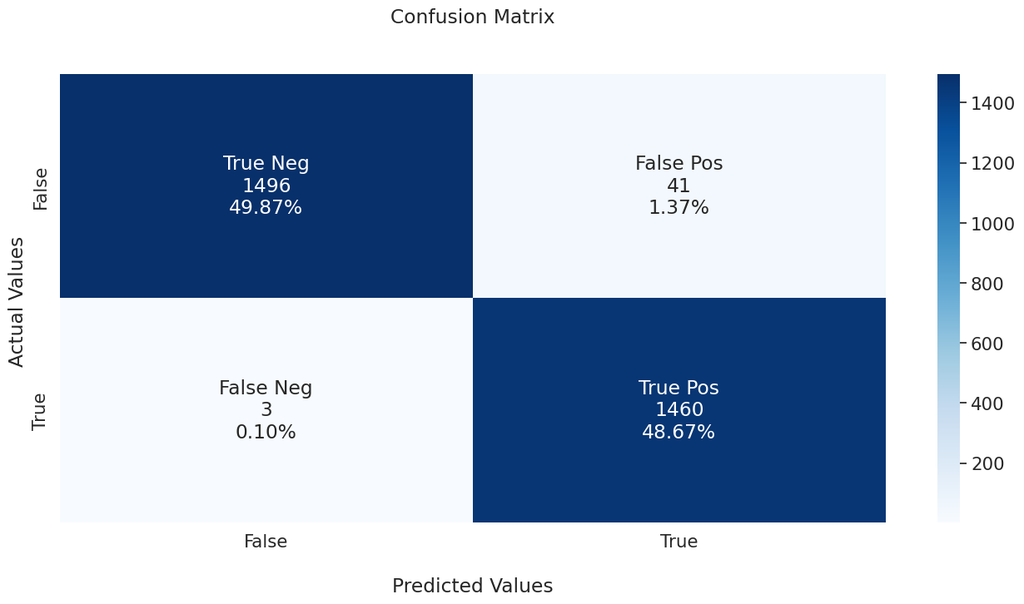

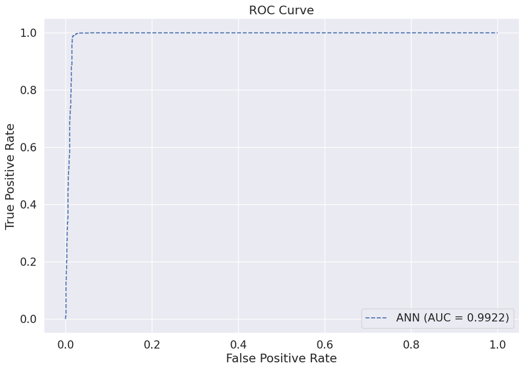

```python
# Create the ANN model
model_4 = Sequential()
model_4.add(Dense(1000, activation='relu', input_shape=(78,), kernel_constraint=MaxNorm(3)))
model_4.add(Dropout(0.7))
model_4.add(BatchNormalization())

model_4.add(Dense(750, activation='relu', kernel_constraint=MaxNorm(3)))
model_4.add(Dropout(0.7))
model_4.add(BatchNormalization())

model_4.add(Dense(1, activation='sigmoid', kernel_constraint=MaxNorm(3)))
model_4.summary()

# Compile the model
model_4.compile(loss='binary_crossentropy', optimizer='adam', metrics=['accuracy'])

# Training time
start_train = time.time()
history = model_4.fit(X_train, y_train, epochs=10, batch_size=256,
                      validation_data=(X_test, y_test), verbose=1, shuffle=False)
end_train = time.time()
training_time = end_train - start_train
print(f"Training Time: {training_time:.2f} seconds")

# Testing time
start_test = time.time()
loss, accuracy = model_4.evaluate(X_test, y_test)
end_test = time.time()
testing_time = end_test - start_test
print(f"Testing Time: {testing_time:.2f} seconds")

# Total time
total_time = training_time + testing_time
print(f"Total Time (Training + Testing): {total_time:.2f} seconds")

print(f"Test Accuracy: {accuracy:.4f}")

# Make predictions
y_pred_prob = model_4.predict(X_test)
y_pred = np.round(y_pred_prob).astype(int)  # Convert predictions to binary

# Calculate various metrics
accuracy = accuracy_score(y_test, y_pred)
precision = precision_score(y_test, y_pred)
recall = recall_score(y_test, y_pred)
f1 = f1_score(y_test, y_pred)
mcc = matthews_corrcoef(y_test, y_pred)
roc_auc4 = roc_auc_score(y_test, y_pred_prob)

# Print metrics
print(f"Accuracy: {accuracy:.4f}")
print(f"Precision: {precision:.4f}")
print(f"Recall: {recall:.4f}")
print(f"F1 Score: {f1:.4f}")
print(f"Matthews Correlation Coefficient: {mcc:.4f}")
print(f"ROC AUC Score: {roc_auc4:.4f}")
print("Classification Report:\n", classification_report(y_test, y_pred))

# Confusion matrix
conf_matrix = confusion_matrix(y_test, y_pred)

plt.figure(figsize=(16, 7))
sns.set(font_scale=1.4)

group_names = ['True Neg', 'False Pos', 'False Neg', 'True Pos']
group_counts = ["{0:0.0f}".format(value) for value in conf_matrix.flatten()]
group_percentages = ["{0:.2%}".format(value) for value in conf_matrix.flatten()/np.sum(conf_matrix)]

labels = [f"{v1}\n{v2}\n{v3}" for v1, v2, v3 in zip(group_names, group_counts, group_percentages)]
labels = np.asarray(labels).reshape(2, 2)

ax = sns.heatmap(conf_matrix, annot=labels, fmt='', cmap='Blues')
ax.set_title('Confusion Matrix\n\n')
ax.set_xlabel('\nPredicted Values')
ax.set_ylabel('Actual Values ')
ax.xaxis.set_ticklabels(['False', 'True'])
ax.yaxis.set_ticklabels(['False', 'True'])
plt.show()

print('*******************************************')

# ROC curve and AUC
fpr4, tpr4, _ = roc_curve(y_test, y_pred_prob)

plt.figure(figsize=(12, 8))
plt.plot(fpr4, tpr4, linestyle='--', label=f'ANN (AUC = {roc_auc4:.4f})')

plt.title('ROC Curve')
plt.xlabel('False Positive Rate')
plt.ylabel('True Positive Rate')
plt.legend()
plt.show()
```

# RNN-Model

```
Model: "RNN-Model"
```

```
┏━━━━━━━━━━━━━━━━━━━━━━━━━━━━━━━━━┳━━━━━━━━━━━━━━━━━━━━━━━━┳━━━━━━━━━━━━━━━┓
┃ Layer (type)                    ┃ Output Shape           ┃       Param # ┃
┡━━━━━━━━━━━━━━━━━━━━━━━━━━━━━━━━━╇━━━━━━━━━━━━━━━━━━━━━━━━╇━━━━━━━━━━━━━━━┩
│ simple_rnn (SimpleRNN)          │ (None, 78, 128)        │        16,640 │
├─────────────────────────────────┼────────────────────────┼───────────────┤
│ simple_rnn_1 (SimpleRNN)        │ (None, 78, 64)         │        12,352 │
├─────────────────────────────────┼────────────────────────┼───────────────┤
│ dropout_11 (Dropout)            │ (None, 78, 64)         │             0 │
├─────────────────────────────────┼────────────────────────┼───────────────┤
│ simple_rnn_2 (SimpleRNN)        │ (None, 32)             │         3,104 │
├─────────────────────────────────┼────────────────────────┼───────────────┤
│ flatten_2 (Flatten)             │ (None, 32)             │             0 │
├─────────────────────────────────┼────────────────────────┼───────────────┤
│ dense_13 (Dense)                │ (None, 32)             │         1,056 │
├─────────────────────────────────┼────────────────────────┼───────────────┤
│ dropout_12 (Dropout)            │ (None, 32)             │             0 │
├─────────────────────────────────┼────────────────────────┼───────────────┤
│ dense_14 (Dense)                │ (None, 1)              │            33 │
├─────────────────────────────────┼────────────────────────┼───────────────┤
│ activation_2 (Activation)       │ (None, 1)              │             0 │
└─────────────────────────────────┴────────────────────────┴───────────────┘
```

```
 Total params: 33,185 (129.63 KB)
```

```
 Trainable params: 33,185 (129.63 KB)
```

```
 Non-trainable params: 0 (0.00 B)
```

```
28/28 ━━━━━━━━━━━━━━━━━━━━ 13s 194ms/step - accuracy: 0.8698 - loss: 0.3325 - val_accuracy: 0.9827 - val_loss: 0.0794
28/28 ━━━━━━━━━━━━━━━━━━━━ 1s 25ms/step - accuracy: 0.9812 - loss: 0.0810 - val_accuracy: 0.9837 - val_loss: 0.0695
28/28 ━━━━━━━━━━━━━━━━━━━━ 1s 24ms/step - accuracy: 0.9832 - loss: 0.0677 - val_accuracy: 0.9853 - val_loss: 0.0582
28/28 ━━━━━━━━━━━━━━━━━━━━ 1s 24ms/step - accuracy: 0.9832 - loss: 0.0649 - val_accuracy: 0.9833 - val_loss: 0.0585
28/28 ━━━━━━━━━━━━━━━━━━━━ 1s 24ms/step - accuracy: 0.9836 - loss: 0.0625 - val_accuracy: 0.9867 - val_loss: 0.0536
28/28 ━━━━━━━━━━━━━━━━━━━━ 1s 24ms/step - accuracy: 0.9835 - loss: 0.0592 - val_accuracy: 0.9847 - val_loss: 0.0557
28/28 ━━━━━━━━━━━━━━━━━━━━ 1s 24ms/step - accuracy: 0.9839 - loss: 0.0599 - val_accuracy: 0.9857 - val_loss: 0.0554
28/28 ━━━━━━━━━━━━━━━━━━━━ 1s 24ms/step - accuracy: 0.9848 - loss: 0.0574 - val_accuracy: 0.9843 - val_loss: 0.0524
28/28 ━━━━━━━━━━━━━━━━━━━━ 1s 24ms/step - accuracy: 0.9842 - loss: 0.0567 - val_accuracy: 0.9837 - val_loss: 0.0573
28/28 ━━━━━━━━━━━━━━━━━━━━ 1s 24ms/step - accuracy: 0.9874 - loss: 0.0564 - val_accuracy: 0.9847 - val_loss: 0.0535
Training Time: 19.53 seconds
94/94 ━━━━━━━━━━━━━━━━━━━━ 2s 12ms/step - accuracy: 0.9817 - loss: 0.0570
Testing Time: 1.70 seconds
Total (Training + Testing) Time: 21.23 seconds
Test Accuracy: 0.984666645526886
94/94 ━━━━━━━━━━━━━━━━━━━━ 2s 14ms/step
Precision: 0.9707641196013289
Recall: 0.9986329460013671
F1 Score: 0.9845013477088949
Matthews Correlation Coefficient: 0.969715995285249
ROC AUC Score: 0.9935529662270064
Classification Report:
               precision    recall  f1-score   support

           0       1.00      0.97      0.98      1537
           1       0.97      1.00      0.98      1463

    accuracy                           0.98      3000
   macro avg       0.98      0.99      0.98      3000
weighted avg       0.99      0.98      0.98      3000
```

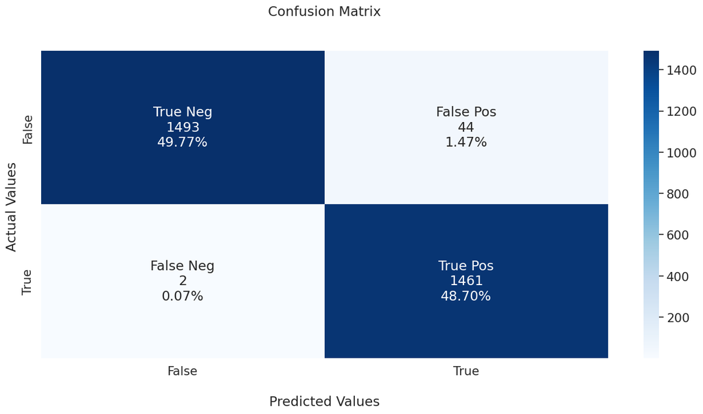

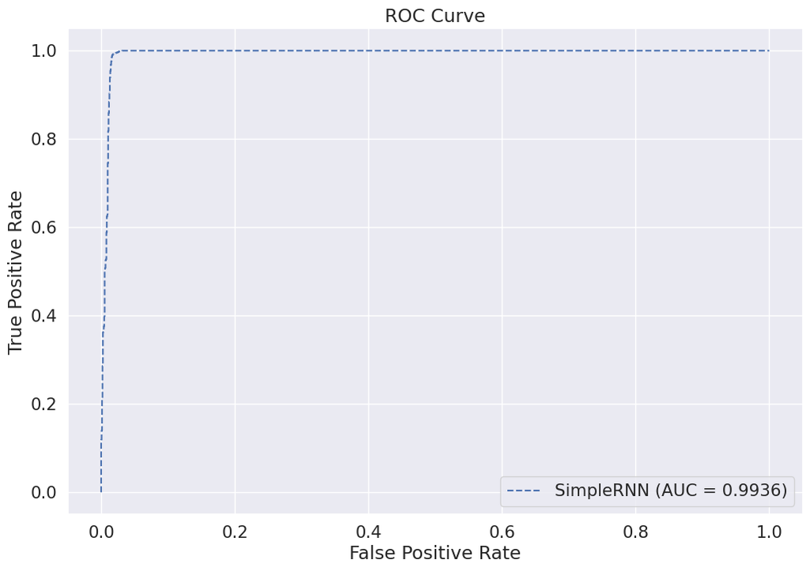

```python
# Define the model using RNN
model_5 = Sequential(name="RNN-Model")
model_5.add(SimpleRNN(units=128, input_shape=(78, 1), return_sequences=True))
model_5.add(SimpleRNN(units=64, return_sequences=True))
model_5.add(Dropout(0.01))
model_5.add(SimpleRNN(32))
model_5.add(Flatten())
model_5.add(Dense(units=32, activation='relu'))
model_5.add(Dropout(0.01))
model_5.add(Dense(units=1))
model_5.add(Activation('sigmoid'))
model_5.summary()

# Compile the model
model_5.compile(loss='binary_crossentropy', optimizer='adam', metrics=['accuracy'])

# Track training time
start_train = time.time()
history = model_5.fit(
    X_train, y_train,
    epochs=10,
    batch_size=256,
    validation_data=(X_test, y_test),
    verbose=1,
    shuffle=False
)
end_train = time.time()
training_time = end_train - start_train
print(f"Training Time: {training_time:.2f} seconds")

# Track testing (evaluation) time
start_test = time.time()
loss, accuracy = model_5.evaluate(X_test, y_test)
end_test = time.time()
testing_time = end_test - start_test
print(f"Testing Time: {testing_time:.2f} seconds")

# Total time
total_time = training_time + testing_time
print(f"Total (Training + Testing) Time: {total_time:.2f} seconds")

print(f"Test Accuracy: {accuracy}")

# Make predictions
y_pred_prob = model_5.predict(X_test)
y_pred = np.round(y_pred_prob).astype(int)  # Convert predictions to binary

# Calculate various metrics
precision = precision_score(y_test, y_pred)
recall = recall_score(y_test, y_pred)
f1 = f1_score(y_test, y_pred)
mcc = matthews_corrcoef(y_test, y_pred)
roc_auc5 = roc_auc_score(y_test, y_pred_prob)

# Print metrics
print(f"Precision: {precision}")
print(f"Recall: {recall}")
print(f"F1 Score: {f1}")
print(f"Matthews Correlation Coefficient: {mcc}")
print(f"ROC AUC Score: {roc_auc5}")
print("Classification Report:\n", classification_report(y_test, y_pred))

# Confusion matrix
conf_matrix = confusion_matrix(y_test, y_pred)

plt.figure(figsize=(16, 7))
sns.set(font_scale=1.4)

group_names = ['True Neg', 'False Pos', 'False Neg', 'True Pos']
group_counts = ["{0:0.0f}".format(value) for value in conf_matrix.flatten()]
group_percentages = ["{0:.2%}".format(value) for value in conf_matrix.flatten() / np.sum(conf_matrix)]

labels = [f"{v1}\n{v2}\n{v3}" for v1, v2, v3 in zip(group_names, group_counts, group_percentages)]
labels = np.asarray(labels).reshape(2, 2)

ax = sns.heatmap(conf_matrix, annot=labels, fmt='', cmap='Blues')
ax.set_title('Confusion Matrix\n\n')
ax.set_xlabel('\nPredicted Values')
ax.set_ylabel('Actual Values ')
ax.xaxis.set_ticklabels(['False', 'True'])
ax.yaxis.set_ticklabels(['False', 'True'])

plt.show()

print('*******************************************')

# ROC curve and AUC
fpr5, tpr5, _ = roc_curve(y_test, y_pred_prob)

plt.figure(figsize=(12, 8))
plt.plot(fpr5, tpr5, linestyle='--', label=f'SimpleRNN (AUC = {roc_auc5:.4f})')

plt.title('ROC Curve')
plt.xlabel('False Positive Rate')
plt.ylabel('True Positive Rate')
plt.legend()
plt.show()
```

```
Model: "GRU-Model"
```

```
┏━━━━━━━━━━━━━━━━━━━━━━━━━━━━━━━━━┳━━━━━━━━━━━━━━━━━━━━━━━━┳━━━━━━━━━━━━━━━┓
┃ Layer (type)                    ┃ Output Shape           ┃       Param # ┃
┡━━━━━━━━━━━━━━━━━━━━━━━━━━━━━━━━━╇━━━━━━━━━━━━━━━━━━━━━━━━╇━━━━━━━━━━━━━━━┩
│ gru (GRU)                       │ (None, 78, 128)        │        50,304 │
├─────────────────────────────────┼────────────────────────┼───────────────┤
│ gru_1 (GRU)                     │ (None, 78, 64)         │        37,248 │
├─────────────────────────────────┼────────────────────────┼───────────────┤
│ dropout_13 (Dropout)            │ (None, 78, 64)         │             0 │
├─────────────────────────────────┼────────────────────────┼───────────────┤
│ flatten_3 (Flatten)             │ (None, 4992)           │             0 │
├─────────────────────────────────┼────────────────────────┼───────────────┤
│ dense_15 (Dense)                │ (None, 32)             │       159,776 │
├─────────────────────────────────┼────────────────────────┼───────────────┤
│ dropout_14 (Dropout)            │ (None, 32)             │             0 │
├─────────────────────────────────┼────────────────────────┼───────────────┤
│ dense_16 (Dense)                │ (None, 1)              │            33 │
├─────────────────────────────────┼────────────────────────┼───────────────┤
│ activation_3 (Activation)       │ (None, 1)              │             0 │
└─────────────────────────────────┴────────────────────────┴───────────────┘
```

```
 Total params: 247,361 (966.25 KB)
```

```
 Trainable params: 247,361 (966.25 KB)
```

```
 Non-trainable params: 0 (0.00 B)
```

```
28/28 ━━━━━━━━━━━━━━━━━━━━ 4s 40ms/step - accuracy: 0.7942 - loss: 0.4437 - val_accuracy: 0.9730 - val_loss: 0.1190
28/28 ━━━━━━━━━━━━━━━━━━━━ 1s 17ms/step - accuracy: 0.9737 - loss: 0.1076 - val_accuracy: 0.9817 - val_loss: 0.0811
28/28 ━━━━━━━━━━━━━━━━━━━━ 1s 17ms/step - accuracy: 0.9804 - loss: 0.0830 - val_accuracy: 0.9833 - val_loss: 0.0705
28/28 ━━━━━━━━━━━━━━━━━━━━ 1s 17ms/step - accuracy: 0.9824 - loss: 0.0749 - val_accuracy: 0.9843 - val_loss: 0.0663
28/28 ━━━━━━━━━━━━━━━━━━━━ 1s 18ms/step - accuracy: 0.9815 - loss: 0.0694 - val_accuracy: 0.9853 - val_loss: 0.0634
28/28 ━━━━━━━━━━━━━━━━━━━━ 1s 17ms/step - accuracy: 0.9831 - loss: 0.0653 - val_accuracy: 0.9850 - val_loss: 0.0625
28/28 ━━━━━━━━━━━━━━━━━━━━ 1s 17ms/step - accuracy: 0.9825 - loss: 0.0656 - val_accuracy: 0.9863 - val_loss: 0.0621
28/28 ━━━━━━━━━━━━━━━━━━━━ 1s 18ms/step - accuracy: 0.9838 - loss: 0.0642 - val_accuracy: 0.9860 - val_loss: 0.0612
28/28 ━━━━━━━━━━━━━━━━━━━━ 1s 18ms/step - accuracy: 0.9846 - loss: 0.0609 - val_accuracy: 0.9860 - val_loss: 0.0605
28/28 ━━━━━━━━━━━━━━━━━━━━ 1s 18ms/step - accuracy: 0.9848 - loss: 0.0603 - val_accuracy: 0.9847 - val_loss: 0.0606
Training Time: 9.12 seconds
94/94 ━━━━━━━━━━━━━━━━━━━━ 0s 5ms/step - accuracy: 0.9808 - loss: 0.0666
Testing Time: 0.51 seconds
Total (Training + Testing) Time: 9.63 seconds
Test Accuracy: 0.984666645526886
94/94 ━━━━━━━━━━━━━━━━━━━━ 1s 6ms/step
Precision: 0.9758226997985225
Recall: 0.9931647300068353
F1 Score: 0.9844173441734417
Matthews Correlation Coefficient: 0.9694734851825997
ROC AUC Score: 0.992820298217004
Classification Report:
               precision    recall  f1-score   support

           0       0.99      0.98      0.98      1537
           1       0.98      0.99      0.98      1463

    accuracy                           0.98      3000
   macro avg       0.98      0.98      0.98      3000
weighted avg       0.98      0.98      0.98      3000
```

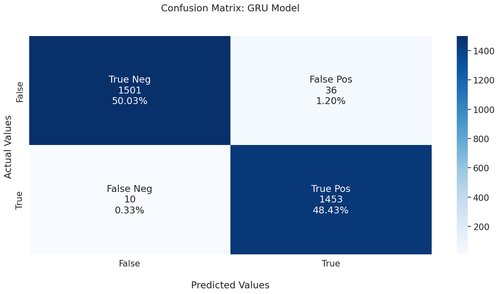

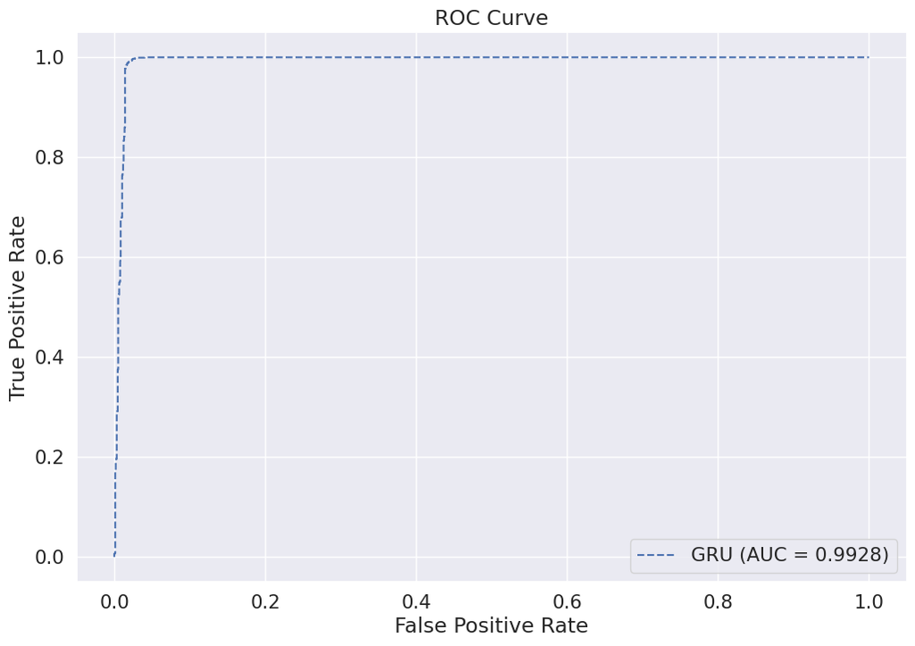

```python
import time
from tensorflow.keras.models import Sequential
from tensorflow.keras.layers import GRU, Dropout, Flatten, Dense, Activation
from sklearn.metrics import (
    precision_score, recall_score, f1_score, matthews_corrcoef,
    roc_auc_score, classification_report, confusion_matrix, roc_curve
)
import seaborn as sns
import matplotlib.pyplot as plt
import numpy as np

# Define the model using GRU
model_gru = Sequential(name="GRU-Model")
model_gru.add(GRU(units=128, input_shape=(78, 1), return_sequences=True))
model_gru.add(GRU(units=64, return_sequences=True))
model_gru.add(Dropout(0.03))
model_gru.add(Flatten())
model_gru.add(Dense(units=32, activation='relu'))
model_gru.add(Dropout(0.03))
model_gru.add(Dense(units=1))
model_gru.add(Activation('sigmoid'))
model_gru.summary()

# Compile the model
model_gru.compile(loss='binary_crossentropy', optimizer='adam', metrics=['accuracy'])

# Track training time
start_train = time.time()
history = model_gru.fit(
    X_train, y_train,
    epochs=10,
    batch_size=256,
    validation_data=(X_test, y_test),
    verbose=1,
    shuffle=False
)
end_train = time.time()
training_time = end_train - start_train
print(f"Training Time: {training_time:.2f} seconds")

# Track testing (evaluation) time
start_test = time.time()
loss, accuracy = model_gru.evaluate(X_test, y_test)
end_test = time.time()
testing_time = end_test - start_test
print(f"Testing Time: {testing_time:.2f} seconds")

# Total time
total_time = training_time + testing_time
print(f"Total (Training + Testing) Time: {total_time:.2f} seconds")

print(f"Test Accuracy: {accuracy}")

# Make predictions
y_pred_prob = model_gru.predict(X_test)
y_pred = np.round(y_pred_prob).astype(int)  # Convert predictions to binary

# Calculate various metrics
precision = precision_score(y_test, y_pred)
recall = recall_score(y_test, y_pred)
f1 = f1_score(y_test, y_pred)
mcc = matthews_corrcoef(y_test, y_pred)
roc_auc_gru = roc_auc_score(y_test, y_pred_prob)

# Print metrics
print(f"Precision: {precision}")
print(f"Recall: {recall}")
print(f"F1 Score: {f1}")
print(f"Matthews Correlation Coefficient: {mcc}")
print(f"ROC AUC Score: {roc_auc_gru}")
print("Classification Report:\n", classification_report(y_test, y_pred))

# Confusion matrix
conf_matrix = confusion_matrix(y_test, y_pred)

plt.figure(figsize=(16, 7))
sns.set(font_scale=1.4)

group_names = ['True Neg', 'False Pos', 'False Neg', 'True Pos']
group_counts = ["{0:0.0f}".format(value) for value in conf_matrix.flatten()]
group_percentages = ["{0:.2%}".format(value) for value in conf_matrix.flatten() / np.sum(conf_matrix)]

labels = [f"{v1}\n{v2}\n{v3}" for v1, v2, v3 in zip(group_names, group_counts, group_percentages)]
labels = np.asarray(labels).reshape(2, 2)

ax = sns.heatmap(conf_matrix, annot=labels, fmt='', cmap='Blues')
ax.set_title('Confusion Matrix: GRU Model\n\n')
ax.set_xlabel('\nPredicted Values')
ax.set_ylabel('Actual Values ')
ax.xaxis.set_ticklabels(['False', 'True'])
ax.yaxis.set_ticklabels(['False', 'True'])

plt.show()

print('*******************************************')

# ROC curve and AUC
fpr_gru, tpr_gru, _ = roc_curve(y_test, y_pred_prob)

plt.figure(figsize=(12, 8))
plt.plot(fpr_gru, tpr_gru, linestyle='--', label=f'GRU (AUC = {roc_auc_gru:.4f})')

plt.title('ROC Curve')
plt.xlabel('False Positive Rate')
plt.ylabel('True Positive Rate')
plt.legend()
plt.show()
```

```
Iteration 1/5, Best Fitness = 0.9871
Iteration 2/5, Best Fitness = 0.9879
Iteration 3/5, Best Fitness = 0.9879
Iteration 4/5, Best Fitness = 0.9879
Iteration 5/5, Best Fitness = 0.9879

Best Hyperparameters from Bee Algorithm:
  GRU Units Layer1 : 85
  GRU Units Layer2 : 71
  Dropout          : 0.010
  Batch Size       : 52
135/135 ━━━━━━━━━━━━━━━━━━━━ 5s 16ms/step - accuracy: 0.9005 - loss: 0.2662 - val_accuracy: 0.9823 - val_loss: 0.0729
135/135 ━━━━━━━━━━━━━━━━━━━━ 2s 12ms/step - accuracy: 0.9822 - loss: 0.0771 - val_accuracy: 0.9830 - val_loss: 0.0670
135/135 ━━━━━━━━━━━━━━━━━━━━ 2s 12ms/step - accuracy: 0.9836 - loss: 0.0681 - val_accuracy: 0.9840 - val_loss: 0.0654
135/135 ━━━━━━━━━━━━━━━━━━━━ 2s 12ms/step - accuracy: 0.9844 - loss: 0.0636 - val_accuracy: 0.9837 - val_loss: 0.0635
135/135 ━━━━━━━━━━━━━━━━━━━━ 2s 12ms/step - accuracy: 0.9836 - loss: 0.0606 - val_accuracy: 0.9837 - val_loss: 0.0642
135/135 ━━━━━━━━━━━━━━━━━━━━ 2s 12ms/step - accuracy: 0.9842 - loss: 0.0578 - val_accuracy: 0.9827 - val_loss: 0.0638
135/135 ━━━━━━━━━━━━━━━━━━━━ 2s 12ms/step - accuracy: 0.9840 - loss: 0.0573 - val_accuracy: 0.9830 - val_loss: 0.0633
135/135 ━━━━━━━━━━━━━━━━━━━━ 2s 12ms/step - accuracy: 0.9845 - loss: 0.0556 - val_accuracy: 0.9830 - val_loss: 0.0616
135/135 ━━━━━━━━━━━━━━━━━━━━ 2s 12ms/step - accuracy: 0.9861 - loss: 0.0532 - val_accuracy: 0.9840 - val_loss: 0.0594
135/135 ━━━━━━━━━━━━━━━━━━━━ 2s 12ms/step - accuracy: 0.9860 - loss: 0.0524 - val_accuracy: 0.9833 - val_loss: 0.0576
94/94 ━━━━━━━━━━━━━━━━━━━━ 0s 5ms/step - accuracy: 0.9805 - loss: 0.0647

 Training Time: 19.78 seconds
 Testing Time: 0.54 seconds
 Total Time: 20.32 seconds
 Final Test Accuracy: 0.9833
94/94 ━━━━━━━━━━━━━━━━━━━━ 1s 5ms/step
Precision: 0.9701
Recall: 0.9966
F1 Score: 0.9831
MCC: 0.9670
ROC AUC: 0.9935

Classification Report:
               precision    recall  f1-score   support

           0       1.00      0.97      0.98      1537
           1       0.97      1.00      0.98      1463

    accuracy                           0.98      3000
   macro avg       0.98      0.98      0.98      3000
weighted avg       0.98      0.98      0.98      3000
```

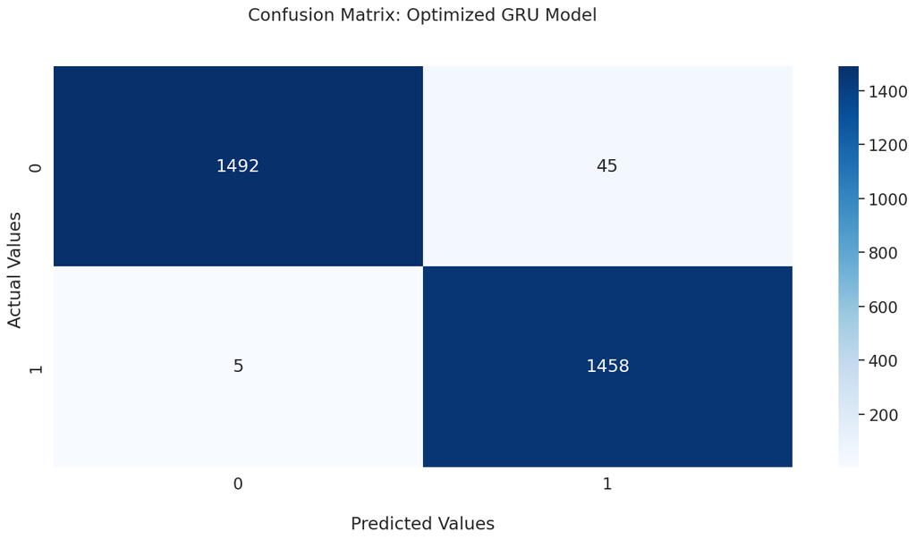

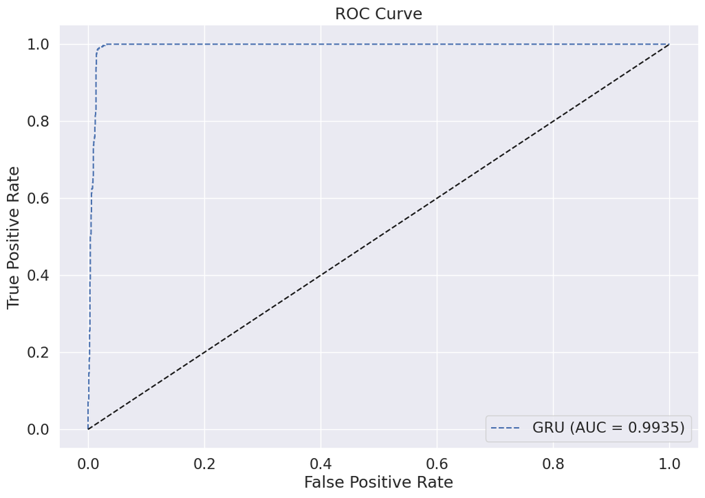

```python
# -----------------------------------------------------------
# Define Search Space: [units1, units2, dropout, batch_size]
# -----------------------------------------------------------
bounds = (
    np.array([32, 16, 0.01, 32]),   # lower bounds
    np.array([256, 128, 0.5, 512])  # upper bounds
)

# -----------------------------------------------------------
# Objective Function
# -----------------------------------------------------------
def objective_function(params):
    losses = []
    for p in params:
        units1 = int(p[0])
        units2 = int(p[1])
        dropout = float(p[2])
        batch_size = int(p[3])

        # Define GRU model
        model = Sequential(name="GRU-Model")
        model.add(GRU(units=units1, input_shape=(78, 1), return_sequences=True))
        model.add(GRU(units=units2, return_sequences=True))
        model.add(Dropout(dropout))
        model.add(Flatten())
        model.add(Dense(units=32, activation='relu'))
        model.add(Dropout(dropout))
        model.add(Dense(units=1))
        model.add(Activation('sigmoid'))

        model.compile(loss='binary_crossentropy', optimizer=Adam(), metrics=['accuracy'])

        # Train (only few epochs for optimization speed)
        history = model.fit(
            X_train, y_train,
            epochs=3,
            batch_size=batch_size,
            validation_split=0.2,
            verbose=0,
            shuffle=False
        )

        val_acc = np.max(history.history['val_accuracy'])
        losses.append(1 - val_acc)  # minimize loss (maximize val_acc)
    return np.array(losses)

# -----------------------------------------------------------
# Bee Algorithm
# -----------------------------------------------------------
class BeeOptimizer:
    def __init__(self, n_bees, n_elite, n_best, patch_size, bounds, max_iter):
        self.n_bees = n_bees
        self.n_elite = n_elite
        self.n_best = n_best
        self.patch_size = patch_size
        self.bounds = bounds
        self.max_iter = max_iter

    def optimize(self):
        population = np.random.uniform(self.bounds[0], self.bounds[1], (self.n_bees, len(self.bounds[0])))
        best_solution = None
        best_fitness = float('inf')

        for iteration in range(self.max_iter):
            fitness = objective_function(population)
            sorted_indices = np.argsort(fitness)
            population = population[sorted_indices]
            fitness = fitness[sorted_indices]

            if fitness[0] < best_fitness:
                best_fitness = fitness[0]
                best_solution = population[0]

            print(f"Iteration {iteration+1}/{self.max_iter}, Best Fitness = {1-best_fitness:.4f}")

            new_population = []
            for i in range(self.n_elite):
                for _ in range(self.n_best):
                    candidate = population[i] + np.random.uniform(-self.patch_size, self.patch_size, len(self.bounds[0]))
                    candidate = np.clip(candidate, self.bounds[0], self.bounds[1])
                    new_population.append(candidate)

            for i in range(self.n_elite, self.n_best + self.n_elite):
                if i < len(population):
                    candidate = population[i] + np.random.uniform(-self.patch_size, self.patch_size, len(self.bounds[0]))
                    candidate = np.clip(candidate, self.bounds[0], self.bounds[1])
                    new_population.append(candidate)

            while len(new_population) < self.n_bees:
                candidate = np.random.uniform(self.bounds[0], self.bounds[1], len(self.bounds[0]))
                new_population.append(candidate)

            population = np.array(new_population)

        return best_solution, 1 - best_fitness

# -----------------------------------------------------------
# Run Bee Algorithm
# -----------------------------------------------------------
optimizer = BeeOptimizer(n_bees=10, n_elite=3, n_best=3, patch_size=10, bounds=bounds, max_iter=5)
best_params, best_acc = optimizer.optimize()

best_units1 = int(best_params[0])
best_units2 = int(best_params[1])
best_dropout = float(best_params[2])
best_batch = int(best_params[3])

print("\nBest Hyperparameters from Bee Algorithm:")
print(f"  GRU Units Layer1 : {best_units1}")
print(f"  GRU Units Layer2 : {best_units2}")
print(f"  Dropout          : {best_dropout:.3f}")
print(f"  Batch Size       : {best_batch}")

# -----------------------------------------------------------
# Final GRU Training with Best Hyperparameters
# -----------------------------------------------------------
model_gru = Sequential(name="Optimized-GRU-Model")
model_gru.add(GRU(units=best_units1, input_shape=(78, 1), return_sequences=True))
model_gru.add(GRU(units=best_units2, return_sequences=True))
model_gru.add(Dropout(best_dropout))
model_gru.add(Flatten())
model_gru.add(Dense(units=32, activation='relu'))
model_gru.add(Dropout(best_dropout))
model_gru.add(Dense(units=1))
model_gru.add(Activation('sigmoid'))

model_gru.compile(loss='binary_crossentropy', optimizer=Adam(), metrics=['accuracy'])

# Training + Testing with Time
start_train = time.time()
history = model_gru.fit(
    X_train, y_train,
    epochs=10,
    batch_size=best_batch,
    validation_data=(X_test, y_test),
    verbose=1,
    shuffle=False
)
end_train = time.time()
train_time = end_train - start_train

start_test = time.time()
loss, accuracy = model_gru.evaluate(X_test, y_test)
end_test = time.time()
test_time = end_test - start_test

print(f"\n Training Time: {train_time:.2f} seconds")
print(f" Testing Time: {test_time:.2f} seconds")
print(f" Total Time: {train_time+test_time:.2f} seconds")
print(f" Final Test Accuracy: {accuracy:.4f}")

# -----------------------------------------------------------
# Evaluation Metrics
# -----------------------------------------------------------
y_pred_prob = model_gru.predict(X_test)
y_pred = np.round(y_pred_prob).astype(int)

precision = precision_score(y_test, y_pred)
recall = recall_score(y_test, y_pred)
f1 = f1_score(y_test, y_pred)
mcc = matthews_corrcoef(y_test, y_pred)
roc_auc_gru = roc_auc_score(y_test, y_pred_prob)

print(f"Precision: {precision:.4f}")
print(f"Recall: {recall:.4f}")
print(f"F1 Score: {f1:.4f}")
print(f"MCC: {mcc:.4f}")
print(f"ROC AUC: {roc_auc_gru:.4f}")
print("\nClassification Report:\n", classification_report(y_test, y_pred))

# -----------------------------------------------------------
# Confusion Matrix
# -----------------------------------------------------------
conf_matrix = confusion_matrix(y_test, y_pred)
plt.figure(figsize=(16, 7))
sns.set(font_scale=1.4)
ax = sns.heatmap(conf_matrix, annot=True, fmt='d', cmap='Blues')
ax.set_title('Confusion Matrix: Optimized GRU Model\n\n')
ax.set_xlabel('\nPredicted Values')
ax.set_ylabel('Actual Values ')
plt.show()

# -----------------------------------------------------------
# ROC Curve
# -----------------------------------------------------------
fpr, tpr, _ = roc_curve(y_test, y_pred_prob)
plt.figure(figsize=(12, 8))
plt.plot(fpr, tpr, linestyle='--', label=f'GRU (AUC = {roc_auc_gru:.4f})')
plt.plot([0,1],[0,1],'k--')
plt.title('ROC Curve')
plt.xlabel('False Positive Rate')
plt.ylabel('True Positive Rate')
plt.legend()
plt.show()
```